# Från tidyverse till Python

### Ta bort mellanslag (trim och squish)

stringrGrund

R

```
mutate(d, trimmed = str_trim(text), squished = str_squish(text))
```

Pandas

```
d.assign(
    trimmed=d["text"].str.strip(),
    squished=d["text"].str.replace(r"\s+", " ", regex=True).str.strip(),
)
```

Polars

```
d.with_columns(
    trimmed=pl.col("text").str.strip_chars(),
    squished=pl.col("text").str.replace_all(r"\s+", " ").str.strip_chars(),
)
```

`str_trim` = `strip` (Pandas) / `strip_chars` (Polars). `str_squish` (trimma och slå ihop flera mellanslag till ett) saknar egen funktion, så du kedjar ett `replace` med regexet `\s+` (ett eller flera blanktecken) och en `strip`. Kedjor av `.str.` fungerar som `|>` i R.

**Visa resultat**

R

```r
# A tibble: 5 × 3
  text               trimmed       squished
  <chr>              <chr>         <chr>
1 "Anna Svensson"    Anna Svensson Anna Svensson
2 "  bo   karlsson " bo   karlsson bo karlsson
3 "Cia Öberg"        Cia Öberg     Cia Öberg
4 "Dag Lindberg"     Dag Lindberg  Dag Lindberg
5  <NA>              <NA>          <NA>
```

Pandas

```
               text        trimmed       squished
0     Anna Svensson  Anna Svensson  Anna Svensson
1    bo   karlsson   bo   karlsson    bo karlsson
2         Cia Öberg      Cia Öberg      Cia Öberg
3      Dag Lindberg   Dag Lindberg   Dag Lindberg
4               NaN            NaN            NaN
```

Polars

```
shape: (5, 3)
┌──────────────────┬───────────────┬───────────────┐
│ text             ┆ trimmed       ┆ squished      │
│ ---              ┆ ---           ┆ ---           │
│ str              ┆ str           ┆ str           │
╞══════════════════╪═══════════════╪═══════════════╡
│ Anna Svensson    ┆ Anna Svensson ┆ Anna Svensson │
│   bo   karlsson  ┆ bo   karlsson ┆ bo karlsson   │
│ Cia Öberg        ┆ Cia Öberg     ┆ Cia Öberg     │
│ Dag Lindberg     ┆ Dag Lindberg  ┆ Dag Lindberg  │
│ null             ┆ null          ┆ null          │
└──────────────────┴───────────────┴───────────────┘
```

### Innehåller texten ett mönster?

stringrGrund

R

```
filter(d, str_detect(text, "son"))
```

Pandas

```
d[d["text"].str.contains("son", na=False)]
```

Polars

```
d.filter(pl.col("text").str.contains("son"))
```

`str_detect` = `str.contains`. Mönstret är ett regex i alla tre. Pandas ger saknade värden som resultat, vilket gör att filtret kräver `na=False`. Vill du söka efter en helt vanlig text som innehåller specialtecken som `.` eller `(`, använd `regex=False` (Pandas) eller `literal=True` (Polars), motsvarigheten till `fixed()`.

**Visa resultat**

R

```r
# A tibble: 2 × 1
  text
  <chr>
1 "Anna Svensson"
2 "  bo   karlsson "
```

Pandas

```
               text
0     Anna Svensson
1    bo   karlsson
```

Polars

```
shape: (2, 1)
┌──────────────────┐
│ text             │
│ ---              │
│ str              │
╞══════════════════╡
│ Anna Svensson    │
│   bo   karlsson  │
└──────────────────┘
```

### Sök utan hänsyn till versaler

stringrMellan

R

```
filter(d, str_detect(text, fixed("anna", ignore_case = TRUE)))
```

Pandas

```
d[d["text"].str.contains("anna", case=False, regex=False, na=False)]
```

Polars

```
d.filter(pl.col("text").str.to_lowercase().str.contains("anna", literal=True))
```

Pandas har `case=False`. Polars saknar det argumentet, så gör texten till gemener först. I ett regex kan du också skriva `(?i)` först: `str.contains("(?i)anna")`.

**Visa resultat**

R

```r
# A tibble: 1 × 1
  text
  <chr>
1 Anna Svensson
```

Pandas

```
            text
0  Anna Svensson
```

Polars

```
shape: (1, 1)
┌───────────────┐
│ text          │
│ ---           │
│ str           │
╞═══════════════╡
│ Anna Svensson │
└───────────────┘
```

### Börjar eller slutar med

stringrGrund

R

```
filter(d, str_starts(text, "Dag") | str_ends(text, "berg"))
```

Pandas

```
d[d["text"].str.startswith("Dag", na=False) | d["text"].str.endswith("berg", na=False)]
```

Polars

```
d.filter(pl.col("text").str.starts_with("Dag") | pl.col("text").str.ends_with("berg"))
```

`startswith`/`endswith` i Pandas, `starts_with`/`ends_with` i Polars.

**Visa resultat**

R

```r
# A tibble: 2 × 1
  text
  <chr>
1 Cia Öberg
2 Dag Lindberg
```

Pandas

```
           text
2     Cia Öberg
3  Dag Lindberg
```

Polars

```
shape: (2, 1)
┌──────────────┐
│ text         │
│ ---          │
│ str          │
╞══════════════╡
│ Cia Öberg    │
│ Dag Lindberg │
└──────────────┘
```

### Byt ut text (replace)

stringrGrund

R

```
mutate(d, first = str_replace(text, "n", "N"), all = str_replace_all(text, "n", "N"))
```

Pandas

```
d.assign(first=d["text"].str.replace("n", "N", n=1), all=d["text"].str.replace("n", "N"))
```

Polars

```
d.with_columns(first=pl.col("text").str.replace("n", "N"), all=pl.col("text").str.replace_all("n", "N"))
```

**Pandas `replace` byter ut alla träffar** (som `str_replace_all`); begränsa med `n=1` för bara första. Polars har två funktioner: `replace` (första) och `replace_all` (alla), precis som stringr. Pandas tolkar mönstret som vanlig text om du inte skriver `regex=True`.

**Visa resultat**

R

```r
# A tibble: 5 × 3
  text               first              all
  <chr>              <chr>              <chr>
1 "Anna Svensson"    "ANna Svensson"    "ANNa SveNssoN"
2 "  bo   karlsson " "  bo   karlssoN " "  bo   karlssoN "
3 "Cia Öberg"        "Cia Öberg"        "Cia Öberg"
4 "Dag Lindberg"     "Dag LiNdberg"     "Dag LiNdberg"
5  <NA>               <NA>               <NA>
```

Pandas

```
               text             first               all
0     Anna Svensson     ANna Svensson     ANNa SveNssoN
1    bo   karlsson     bo   karlssoN     bo   karlssoN
2         Cia Öberg         Cia Öberg         Cia Öberg
3      Dag Lindberg      Dag LiNdberg      Dag LiNdberg
4               NaN               NaN               NaN
```

Polars

```
shape: (5, 3)
┌──────────────────┬──────────────────┬──────────────────┐
│ text             ┆ first            ┆ all              │
│ ---              ┆ ---              ┆ ---              │
│ str              ┆ str              ┆ str              │
╞══════════════════╪══════════════════╪══════════════════╡
│ Anna Svensson    ┆ ANna Svensson    ┆ ANNa SveNssoN    │
│   bo   karlsson  ┆   bo   karlssoN  ┆   bo   karlssoN  │
│ Cia Öberg        ┆ Cia Öberg        ┆ Cia Öberg        │
│ Dag Lindberg     ┆ Dag LiNdberg     ┆ Dag LiNdberg     │
│ null             ┆ null             ┆ null             │
└──────────────────┴──────────────────┴──────────────────┘
```

### Ersätt med regex och grupper

stringrMellan

R

```
mutate(d, swapped = str_replace(text, "(\\S+) (\\S+)", "\\2, \\1"))
```

Pandas

```
d.assign(swapped=d["text"].str.replace(r"(\S+) (\S+)", r"\2, \1", regex=True))
```

Polars

```
d.with_columns(swapped=pl.col("text").str.replace(r"(\S+) (\S+)", "$2, $1"))
```

Fångstgrupper `( )` hänvisas till med `\\1` i R, `\1` i Pandas och `$1` i Polars. I Python skriver du regex som *råa strängar* med ett `r` framför citattecknet (`r"\S"`), så slipper du dubbla snedstreck. `\S` betyder "allt utom blanktecken". Obs: i nya Pandas (3.x) matchar `\w` bara ASCII-bokstäver, så `Ö` räknas inte som ett ord-tecken. `\S` fungerar överallt.

**Visa resultat**

R

```r
# A tibble: 5 × 2
  text               swapped
  <chr>              <chr>
1 "Anna Svensson"    "Svensson, Anna"
2 "  bo   karlsson " "  bo   karlsson "
3 "Cia Öberg"        "Öberg, Cia"
4 "Dag Lindberg"     "Lindberg, Dag"
5  <NA>               <NA>
```

Pandas

```
               text           swapped
0     Anna Svensson    Svensson, Anna
1    bo   karlsson     bo   karlsson
2         Cia Öberg        Öberg, Cia
3      Dag Lindberg     Lindberg, Dag
4               NaN               NaN
```

Polars

```
shape: (5, 2)
┌──────────────────┬──────────────────┐
│ text             ┆ swapped          │
│ ---              ┆ ---              │
│ str              ┆ str              │
╞══════════════════╪══════════════════╡
│ Anna Svensson    ┆ Svensson, Anna   │
│   bo   karlsson  ┆   bo   karlsson  │
│ Cia Öberg        ┆ Öberg, Cia       │
│ Dag Lindberg     ┆ Lindberg, Dag    │
│ null             ┆ null             │
└──────────────────┴──────────────────┘
```

### Plocka ut en del av texten (str_extract)

stringrMellan

R

```
mutate(mail, user = str_extract(email, "^[^@]+"))
```

Pandas

```
mail.assign(user=mail["email"].str.extract(r"^([^@]+)", expand=False))
```

Polars

```
mail.with_columns(user=pl.col("email").str.extract(r"^([^@]+)", 1))
```

Både Pandas och Polars kräver att det du vill ha står i en **fångstgrupp** `( )`. Polars tar dessutom gruppens nummer (här 1). Pandas returnerar en tabell om du inte skriver `expand=False`.

**Visa resultat**

R

```r
# A tibble: 4 × 2
  email           user
  <chr>           <chr>
1 anna@foretag.se anna
2 bo@example.com  bo
3 ingen adress    ingen adress
4 cia@foretag.se  cia
```

Pandas

```
             email          user
0  anna@foretag.se          anna
1   bo@example.com            bo
2     ingen adress  ingen adress
3   cia@foretag.se           cia
```

Polars

```
shape: (4, 2)
┌─────────────────┬──────────────┐
│ email           ┆ user         │
│ ---             ┆ ---          │
│ str             ┆ str          │
╞═════════════════╪══════════════╡
│ anna@foretag.se ┆ anna         │
│ bo@example.com  ┆ bo           │
│ ingen adress    ┆ ingen adress │
│ cia@foretag.se  ┆ cia          │
└─────────────────┴──────────────┘
```

### Alla träffar (str_extract_all)

stringrMellan

R

```
t <- tibble(x = c("order 12 and 345", "none", "7"))
mutate(t, nums = str_extract_all(x, "\\d+"))
```

Pandas

```
t = pd.DataFrame({"x": ["order 12 and 345", "none", "7"]})
t.assign(nums=t["x"].str.findall(r"\d+"))
```

Polars

```
t = pl.DataFrame({"x": ["order 12 and 345", "none", "7"]})
t.with_columns(nums=pl.col("x").str.extract_all(r"\d+"))
```

Resultatet är en lista per rad (en *list-kolumn*). Gör om till egna rader med `explode`, se tidyr.

**Visa resultat**

R

```r
# A tibble: 3 × 2
  x                nums
  <chr>            <list>
1 order 12 and 345 <chr [2]>
2 none             <chr [0]>
3 7                <chr [1]>
```

Pandas

```
                  x       nums
0  order 12 and 345  [12, 345]
1              none         []
2                 7        [7]
```

Polars

```
shape: (3, 2)
┌──────────────────┬───────────────┐
│ x                ┆ nums          │
│ ---              ┆ ---           │
│ str              ┆ list[str]     │
╞══════════════════╪═══════════════╡
│ order 12 and 345 ┆ ["12", "345"] │
│ none             ┆ []            │
│ 7                ┆ ["7"]         │
└──────────────────┴───────────────┘
```

### Del av text efter position (str_sub)

stringrGrund

R

```
mutate(d, first3 = str_sub(text, 1, 3), last3 = str_sub(text, -3, -1))
```

Pandas

```
d.assign(first3=d["text"].str[:3], last3=d["text"].str[-3:])
```

Polars

```
d.with_columns(first3=pl.col("text").str.slice(0, 3), last3=pl.col("text").str.slice(-3))
```

Python räknar från 0 och slutet är exkluderat: `str[:3]` = de första 3 tecknen. Negativa tal räknas bakifrån, `str[-3:]` = de tre sista. Polars `slice(start, längd)`.

**Visa resultat**

R

```r
# A tibble: 5 × 3
  text               first3 last3
  <chr>              <chr>  <chr>
1 "Anna Svensson"    "Ann"  "son"
2 "  bo   karlsson " "  b"  "on "
3 "Cia Öberg"        "Cia"  "erg"
4 "Dag Lindberg"     "Dag"  "erg"
5  <NA>               <NA>   <NA>
```

Pandas

```
               text first3 last3
0     Anna Svensson    Ann   son
1    bo   karlsson       b   on
2         Cia Öberg    Cia   erg
3      Dag Lindberg    Dag   erg
4               NaN    NaN   NaN
```

Polars

```
shape: (5, 3)
┌──────────────────┬────────┬───────┐
│ text             ┆ first3 ┆ last3 │
│ ---              ┆ ---    ┆ ---   │
│ str              ┆ str    ┆ str   │
╞══════════════════╪════════╪═══════╡
│ Anna Svensson    ┆ Ann    ┆ son   │
│   bo   karlsson  ┆   b    ┆ on    │
│ Cia Öberg        ┆ Cia    ┆ erg   │
│ Dag Lindberg     ┆ Dag    ┆ erg   │
│ null             ┆ null   ┆ null  │
└──────────────────┴────────┴───────┘
```

### Dela upp text (str_split)

stringrMellan

R

```
mutate(pnames, first = str_split_i(name, " ", 1), last = str_split_i(name, " ", 2))
```

Pandas

```
pnames.assign(first=pnames["name"].str.split(" ").str[0], last=pnames["name"].str.split(" ").str[1])
```

Polars

```
pnames.with_columns(
    first=pl.col("name").str.split(" ").list.get(0),
    last=pl.col("name").str.split(" ").list.get(1),
)
```

`str.split(" ")` ger en lista med delarna. Med `.str[0]` (Pandas) eller `.list.get(0)` (Polars) väljer du ett element, **räknat från 0**. Vill du ha delarna som egna kolumner, se `separate` under tidyr.

**Visa resultat**

R

```r
# A tibble: 3 × 4
  name            age first last
  <chr>         <dbl> <chr> <chr>
1 Anna Svensson    34 Anna  Svensson
2 Bo Karlsson      45 Bo    Karlsson
3 Cia Öberg        29 Cia   Öberg
```

Pandas

```
            name  age first      last
0  Anna Svensson   34  Anna  Svensson
1    Bo Karlsson   45    Bo  Karlsson
2      Cia Öberg   29   Cia     Öberg
```

Polars

```
shape: (3, 4)
┌───────────────┬─────┬───────┬──────────┐
│ name          ┆ age ┆ first ┆ last     │
│ ---           ┆ --- ┆ ---   ┆ ---      │
│ str           ┆ i64 ┆ str   ┆ str      │
╞═══════════════╪═════╪═══════╪══════════╡
│ Anna Svensson ┆ 34  ┆ Anna  ┆ Svensson │
│ Bo Karlsson   ┆ 45  ┆ Bo    ┆ Karlsson │
│ Cia Öberg     ┆ 29  ┆ Cia   ┆ Öberg    │
└───────────────┴─────┴───────┴──────────┘
```

### Sätt ihop text (str_c, paste)

stringrGrund

R

```
mutate(pnames, greeting = str_c("Hej ", name, "!"))
```

Pandas

```
pnames.assign(greeting="Hej " + pnames["name"] + "!")
```

Polars

```
pnames.with_columns(greeting=pl.concat_str([pl.lit("Hej "), pl.col("name"), pl.lit("!")]))
```

I Pandas kan du lägga ihop text-kolumner med `+`. Polars har `concat_str`. Text som står mellan kolumnerna skrivs `pl.lit("...")`. Med `separator=" "` liknar det `paste(..., sep = " ")`.

**Visa resultat**

R

```r
# A tibble: 3 × 3
  name            age greeting
  <chr>         <dbl> <chr>
1 Anna Svensson    34 Hej Anna Svensson!
2 Bo Karlsson      45 Hej Bo Karlsson!
3 Cia Öberg        29 Hej Cia Öberg!
```

Pandas

```
            name  age            greeting
0  Anna Svensson   34  Hej Anna Svensson!
1    Bo Karlsson   45    Hej Bo Karlsson!
2      Cia Öberg   29      Hej Cia Öberg!
```

Polars

```
shape: (3, 3)
┌───────────────┬─────┬────────────────────┐
│ name          ┆ age ┆ greeting           │
│ ---           ┆ --- ┆ ---                │
│ str           ┆ i64 ┆ str                │
╞═══════════════╪═════╪════════════════════╡
│ Anna Svensson ┆ 34  ┆ Hej Anna Svensson! │
│ Bo Karlsson   ┆ 45  ┆ Hej Bo Karlsson!   │
│ Cia Öberg     ┆ 29  ┆ Hej Cia Öberg!     │
└───────────────┴─────┴────────────────────┘
```

### Mallar med värden i (str_glue)

stringrMellan

R

```
mutate(pnames, label = str_glue("{name} är {age} år"))
```

Pandas

```
pnames.assign(label=pnames["name"] + " är " + pnames["age"].astype(str) + " år")
```

Polars

```
pnames.with_columns(label=pl.format("{} är {} år", pl.col("name"), pl.col("age")))
```

Polars `pl.format` fyller `{}` med kolumnerna i ordning. Pandas har ingen motsvarighet för kolumner, så där lägger du ihop delarna. För *enstaka* värden (inte kolumner) har Python f-strängar: `f"{namn} är {alder} år"`.

**Visa resultat**

R

```r
# A tibble: 3 × 3
  name            age label
  <chr>         <dbl> <glue>
1 Anna Svensson    34 Anna Svensson är 34 år
2 Bo Karlsson      45 Bo Karlsson är 45 år
3 Cia Öberg        29 Cia Öberg är 29 år
```

Pandas

```
            name  age                   label
0  Anna Svensson   34  Anna Svensson är 34 år
1    Bo Karlsson   45    Bo Karlsson är 45 år
2      Cia Öberg   29      Cia Öberg är 29 år
```

Polars

```
shape: (3, 3)
┌───────────────┬─────┬────────────────────────┐
│ name          ┆ age ┆ label                  │
│ ---           ┆ --- ┆ ---                    │
│ str           ┆ i64 ┆ str                    │
╞═══════════════╪═════╪════════════════════════╡
│ Anna Svensson ┆ 34  ┆ Anna Svensson är 34 år │
│ Bo Karlsson   ┆ 45  ┆ Bo Karlsson är 45 år   │
│ Cia Öberg     ┆ 29  ┆ Cia Öberg är 29 år     │
└───────────────┴─────┴────────────────────────┘
```

### Fyll ut med nollor (str_pad)

stringrMellan

R

```
mutate(pnames, code = str_pad(age, 4, pad = "0"))
```

Pandas

```
pnames.assign(code=pnames["age"].astype(str).str.zfill(4))
```

Polars

```
pnames.with_columns(code=pl.col("age").cast(pl.String).str.zfill(4))
```

`zfill(4)` fyller på med nollor till fyra tecken. För andra tecken än noll: `str.pad(4, fillchar="x")` (Pandas) och `str.pad_start(4, "x")` (Polars).

**Visa resultat**

R

```r
# A tibble: 3 × 3
  name            age code
  <chr>         <dbl> <chr>
1 Anna Svensson    34 0034
2 Bo Karlsson      45 0045
3 Cia Öberg        29 0029
```

Pandas

```
            name  age  code
0  Anna Svensson   34  0034
1    Bo Karlsson   45  0045
2      Cia Öberg   29  0029
```

Polars

```
shape: (3, 3)
┌───────────────┬─────┬──────┐
│ name          ┆ age ┆ code │
│ ---           ┆ --- ┆ ---  │
│ str           ┆ i64 ┆ str  │
╞═══════════════╪═════╪══════╡
│ Anna Svensson ┆ 34  ┆ 0034 │
│ Bo Karlsson   ┆ 45  ┆ 0045 │
│ Cia Öberg     ┆ 29  ┆ 0029 │
└───────────────┴─────┴──────┘
```

### Räkna förekomster i text

stringrMellan

R

```
mutate(d, n_n = str_count(text, "n"))
```

Pandas

```
d.assign(n_n=d["text"].str.count("n"))
```

Polars

```
d.with_columns(n_n=pl.col("text").str.count_matches("n"))
```

`count` (Pandas) och `count_matches` (Polars) motsvarar `str_count`.

**Visa resultat**

R

```r
# A tibble: 5 × 2
  text                 n_n
  <chr>              <int>
1 "Anna Svensson"        4
2 "  bo   karlsson "     1
3 "Cia Öberg"            0
4 "Dag Lindberg"         1
5  <NA>                 NA
```

Pandas

```
               text  n_n
0     Anna Svensson  4.0
1    bo   karlsson   1.0
2         Cia Öberg  0.0
3      Dag Lindberg  1.0
4               NaN  NaN
```

Polars

```
shape: (5, 2)
┌──────────────────┬──────┐
│ text             ┆ n_n  │
│ ---              ┆ ---  │
│ str              ┆ u32  │
╞══════════════════╪══════╡
│ Anna Svensson    ┆ 4    │
│   bo   karlsson  ┆ 1    │
│ Cia Öberg        ┆ 0    │
│ Dag Lindberg     ┆ 1    │
│ null             ┆ null │
└──────────────────┴──────┘
```

### Ta bort tecken (str_remove_all)

stringrMellan

R

```
mutate(d, letters_only = str_remove_all(text, "[^A-Za-zåäöÅÄÖ]"))
```

Pandas

```
d.assign(letters_only=d["text"].str.replace(r"[^A-Za-zåäöÅÄÖ]", "", regex=True))
```

Polars

```
d.with_columns(letters_only=pl.col("text").str.replace_all(r"[^A-Za-zåäöÅÄÖ]", ""))
```

Det finns ingen egen `remove`-funktion: ersätt med en tom text `""`.

**Visa resultat**

R

```r
# A tibble: 5 × 2
  text               letters_only
  <chr>              <chr>
1 "Anna Svensson"    AnnaSvensson
2 "  bo   karlsson " bokarlsson
3 "Cia Öberg"        CiaÖberg
4 "Dag Lindberg"     DagLindberg
5  <NA>              <NA>
```

Pandas

```
               text  letters_only
0     Anna Svensson  AnnaSvensson
1    bo   karlsson     bokarlsson
2         Cia Öberg      CiaÖberg
3      Dag Lindberg   DagLindberg
4               NaN           NaN
```

Polars

```
shape: (5, 2)
┌──────────────────┬──────────────┐
│ text             ┆ letters_only │
│ ---              ┆ ---          │
│ str              ┆ str          │
╞══════════════════╪══════════════╡
│ Anna Svensson    ┆ AnnaSvensson │
│   bo   karlsson  ┆ bokarlsson   │
│ Cia Öberg        ┆ CiaÖberg     │
│ Dag Lindberg     ┆ DagLindberg  │
│ null             ┆ null         │
└──────────────────┴──────────────┘
```

### Plocka ut tal ur text (parse_number)

stringrMellan

R

```
price <- tibble(text = c("12 kr", "kr 345", "7 kr"))
mutate(price, amount = parse_number(text))
```

Pandas

```
price = pd.DataFrame({"text": ["12 kr", "kr 345", "7 kr"]})
price.assign(amount=price["text"].str.extract(r"(\d+)", expand=False).astype(int))
```

Polars

```
price = pl.DataFrame({"text": ["12 kr", "kr 345", "7 kr"]})
price.with_columns(amount=pl.col("text").str.extract(r"(\d+)", 1).cast(pl.Int64))
```

Ingen färdig `parse_number`. Plocka ut siffrorna med ett regex (`\d+` = en eller flera siffror) och gör om till tal med `astype`/`cast`. Behöver du decimaler, använd `(\d+[.,]?\d*)` och byt komma mot punkt först.

**Visa resultat**

R

```r
# A tibble: 3 × 2
  text   amount
  <chr>   <dbl>
1 12 kr      12
2 kr 345    345
3 7 kr        7
```

Pandas

```
     text  amount
0   12 kr      12
1  kr 345     345
2    7 kr       7
```

Polars

```
shape: (3, 2)
┌────────┬────────┐
│ text   ┆ amount │
│ ---    ┆ ---    │
│ str    ┆ i64    │
╞════════╪════════╡
│ 12 kr  ┆ 12     │
│ kr 345 ┆ 345    │
│ 7 kr   ┆ 7      │
└────────┴────────┘
```

### Slå ihop text från flera rader (str_flatten)

stringrAvancerad

R

```
summarise(pnames, all = str_flatten(name, ", "))
```

Pandas

```
pd.DataFrame({"all": [", ".join(pnames["name"])]})
```

Polars

```
pnames.select(all=pl.col("name").str.join(", "))
```

Här slås **flera rader** ihop till en enda text, vilket är något annat än `concat_str` (som sätter ihop kolumner). Med `group_by` kan det göras per grupp: `.agg(pl.col("name").str.join(", "))` i Polars och `.agg(", ".join)` i Pandas.

**Visa resultat**

R

```r
# A tibble: 1 × 1
  all
  <chr>
1 Anna Svensson, Bo Karlsson, Cia Öberg
```

Pandas

```
                                     all
0  Anna Svensson, Bo Karlsson, Cia Öberg
```

Polars

```
shape: (1, 1)
┌─────────────────────────────────┐
│ all                             │
│ ---                             │
│ str                             │
╞═════════════════════════════════╡
│ Anna Svensson, Bo Karlsson, Ci… │
└─────────────────────────────────┘
```

### Formatera tal som text

stringrMellan

R

```
formatC(1234567.891, format = "f", digits = 2, big.mark = " ")
```

Pythonsamma i Pandas och Polars

```
f"{1234567.891:,.2f}".replace(",", " ")
```

Samma kod i Pandas och Polars. I en f-sträng betyder `:,.2f` "tusentalsavgränsare, 2 decimaler". Python använder komma som tusentalsavgränsare, så vi byter ut det mot ett mellanslag. Andra format: `:.1%` (procent), `:>8` (högerjustera i 8 tecken), `:05d` (nollpad).

**Visa resultat**

R

```r
[1] "1 234 567.89"
```

Python

```
'1 234 567.89'
```

### Flera delar på en gång med regex-grupper (extract)

stringrMellan

R

```
extract(mail, email, into = c("user", "domain"), regex = "^([^@]+)@(.+)$")
```

Pandas

```
mail["email"].str.extract(r"^(?P<user>[^@]+)@(?P<domain>.+)$")
```

Polars

```
mail.select(
    pl.col("email").str.extract_groups(r"^(?P<user>[^@]+)@(?P<domain>.+)$")
).unnest("email")
```

Ge varje fångstgrupp ett namn med `(?P<namn>...)` så blir varje grupp en egen kolumn. Rader som inte matchar (här "ingen adress") ger saknade värden. Polars packar upp gruppresultatet med `unnest`. Se även `separate` under tidyr.

**Visa resultat**

R

```r
# A tibble: 4 × 2
  user  domain
  <chr> <chr>
1 anna  foretag.se
2 bo    example.com
3 <NA>  <NA>
4 cia   foretag.se
```

Pandas

```
   user       domain
0  anna   foretag.se
1    bo  example.com
2   NaN          NaN
3   cia   foretag.se
```

Polars

```
shape: (4, 2)
┌──────┬─────────────┐
│ user ┆ domain      │
│ ---  ┆ ---         │
│ str  ┆ str         │
╞══════╪═════════════╡
│ anna ┆ foretag.se  │
│ bo   ┆ example.com │
│ null ┆ null        │
│ cia  ┆ foretag.se  │
└──────┴─────────────┘
```

## forcats

Kategorier med bestämd ordning (factors)

I R är en *factor* text med en bestämd lista av tillåtna nivåer och en ordning. Det motsvaras av `category` i Pandas och av `Enum` (fast lista med nivåer) i Polars. Du behöver inte alltid göra om text till kategorier i Python. Det är främst när **ordningen** spelar roll (sortering, diagram) som det lönar sig. Exemplen använder tabellen `f` (text) och `fc` (samma tabell där `size` är en kategori med nivåerna S, M, L, XL, men ingen XL finns i data).

**Tabellerna som exemplen använder:**

R

```
library(tidyverse)
f <- tibble(
  size  = c("M", "S", "L", "M", "S", "M", "S", "M"),
  score = c(7, 4, 9, 6, 5, 8, 3, 7)
)
fc <- mutate(f, size = factor(size, levels = c("S", "M", "L", "XL")))
ages <- tibble(age = c(22, 35, 45, 61))
```

Pandas

```
import pandas as pd
import numpy as np

f = pd.DataFrame({
    "size":  ["M", "S", "L", "M", "S", "M", "S", "M"],
    "score": [7, 4, 9, 6, 5, 8, 3, 7],
})
sizes = pd.CategoricalDtype(["S", "M", "L", "XL"], ordered=True)
fc = f.assign(size=f["size"].astype(sizes))
ages = pd.DataFrame({"age": [22, 35, 45, 61]})
```

Polars

```
import polars as pl

f = pl.DataFrame({
    "size":  ["M", "S", "L", "M", "S", "M", "S", "M"],
    "score": [7, 4, 9, 6, 5, 8, 3, 7],
})
sizes = pl.Enum(["S", "M", "L", "XL"])
fc = f.with_columns(pl.col("size").cast(sizes))
ages = pl.DataFrame({"age": [22, 35, 45, 61]})
```

### Skapa en kategori med bestämd ordning

forcatsGrund

R

```
mutate(f, size = factor(size, levels = c("S", "M", "L", "XL")))
```

Pandas

```
sizes = pd.CategoricalDtype(["S", "M", "L", "XL"], ordered=True)
f.assign(size=f["size"].astype(sizes))
```

Polars

```
f.with_columns(pl.col("size").cast(pl.Enum(["S", "M", "L", "XL"])))
```

Pandas: skapa en *typ* med `CategoricalDtype(nivåer, ordered=True)` och använd den i `astype`. Polars: `cast` till `pl.Enum([...])`. Har texten ett värde som inte finns i listan får du ett felmeddelande, vilket är bra för att fånga stavfel.

**Visa resultat**

R

```r
# A tibble: 8 × 2
  size  score
  <fct> <dbl>
1 M         7
2 S         4
3 L         9
4 M         6
5 S         5
6 M         8
7 S         3
8 M         7
```

Pandas

```
  size  score
0    M      7
1    S      4
2    L      9
3    M      6
4    S      5
5    M      8
6    S      3
7    M      7
```

Polars

```
shape: (8, 2)
┌──────┬───────┐
│ size ┆ score │
│ ---  ┆ ---   │
│ enum ┆ i64   │
╞══════╪═══════╡
│ M    ┆ 7     │
│ S    ┆ 4     │
│ L    ┆ 9     │
│ M    ┆ 6     │
│ S    ┆ 5     │
│ M    ┆ 8     │
│ S    ┆ 3     │
│ M    ┆ 7     │
└──────┴───────┘
```

### Sortera efter nivåernas ordning

forcatsGrund

R

```
f |>
  mutate(size = factor(size, levels = c("S", "M", "L", "XL"))) |>
  arrange(size, score)
```

Pandas

```
sizes = pd.CategoricalDtype(["S", "M", "L", "XL"], ordered=True)
f.assign(size=f["size"].astype(sizes)).sort_values(["size", "score"])
```

Polars

```
f.with_columns(pl.col("size").cast(pl.Enum(["S", "M", "L", "XL"]))).sort("size", "score")
```

Utan kategori sorteras texten alfabetiskt (L, M, S), vilket sällan är vad du vill. Med en kategori sorteras den efter nivåernas ordning: S, M, L.

**Visa resultat**

R

```r
# A tibble: 8 × 2
  size  score
  <fct> <dbl>
1 S         3
2 S         4
3 S         5
4 M         6
5 M         7
6 M         7
7 M         8
8 L         9
```

Pandas

```
  size  score
6    S      3
1    S      4
4    S      5
3    M      6
0    M      7
7    M      7
5    M      8
2    L      9
```

Polars

```
shape: (8, 2)
┌──────┬───────┐
│ size ┆ score │
│ ---  ┆ ---   │
│ enum ┆ i64   │
╞══════╪═══════╡
│ S    ┆ 3     │
│ S    ┆ 4     │
│ S    ┆ 5     │
│ M    ┆ 6     │
│ M    ┆ 7     │
│ M    ┆ 7     │
│ M    ┆ 8     │
│ L    ┆ 9     │
└──────┴───────┘
```

### Visa nivåerna (levels)

forcatsGrund

R

```
levels(fc$size)
```

Pandas

```
fc["size"].cat.categories.tolist()
```

Polars

```
fc["size"].dtype.categories.to_list()
```

Nivåerna finns kvar även om ingen rad använder dem (här XL).

**Visa resultat**

R

```r
[1] "S"  "M"  "L"  "XL"
```

Pandas

```
['S', 'M', 'L', 'XL']
```

Polars

```
['S', 'M', 'L', 'XL']
```

### Vänd på ordningen (fct_rev)

forcatsGrund

R

```
levels(fct_rev(fc$size))
```

Pandas

```
fc["size"].cat.categories.tolist()[::-1]
```

Polars

```
fc["size"].dtype.categories.to_list()[::-1]
```

`[::-1]` är Pythons sätt att vända på en lista.

**Visa resultat**

R

```r
[1] "XL" "L"  "M"  "S"
```

Pandas

```
['XL', 'L', 'M', 'S']
```

Polars

```
['XL', 'L', 'M', 'S']
```

### Ordna efter frekvens (fct_infreq)

forcatsMellan

R

```
f2 <- mutate(f, size = fct_infreq(size))
levels(f2$size)
```

Pandas

```
order = f["size"].value_counts().index
f2 = f.assign(size=pd.Categorical(f["size"], categories=order))
f2["size"].cat.categories.tolist()
```

Polars

```
order = f["size"].value_counts(sort=True)["size"]
f2 = f.with_columns(pl.col("size").cast(pl.Enum(order)))
f2["size"].dtype.categories.to_list()
```

Mönstret för att ordna nivåer är alltid detsamma: 1) räkna ut önskad ordning som en lista, 2) skapa kategorin med den listan. `value_counts()` ger nivåerna med vanligaste först. Sista raden visar nivåerna så att du ser att det blev rätt.

**Visa resultat**

R

```r
[1] "M" "S" "L"
```

Pandas

```
['M', 'S', 'L']
```

Polars

```
['M', 'S', 'L']
```

### Ordna efter en annan variabel (fct_reorder)

forcatsMellan

R

```
f2 <- mutate(f, size = fct_reorder(size, score, .fun = mean))
levels(f2$size)
```

Pandas

```
order = f.groupby("size")["score"].mean().sort_values().index
f2 = f.assign(size=pd.Categorical(f["size"], categories=order))
f2["size"].cat.categories.tolist()
```

Polars

```
order = f.group_by("size").agg(pl.col("score").mean()).sort("score")["size"]
f2 = f.with_columns(pl.col("size").cast(pl.Enum(order)))
f2["size"].dtype.categories.to_list()
```

Klassiskt inför ett stapeldiagram: sortera stapeln efter medelvärde. Beräkna medelvärde per nivå, sortera, och använd resultatet som ordning. I plotnine kan du också sortera direkt i diagrammet (se ggplot2).

**Visa resultat**

R

```r
[1] "S" "M" "L"
```

Pandas

```
['S', 'M', 'L']
```

Polars

```
['S', 'M', 'L']
```

### Flytta en nivå först (fct_relevel)

forcatsMellan

R

```
levels(fct_relevel(fc$size, "L"))
```

Pandas

```
cats = fc["size"].cat.categories.tolist()
new_order = ["L"] + [c for c in cats if c != "L"]
fc["size"].cat.reorder_categories(new_order, ordered=True).cat.categories.tolist()
```

Polars

```
cats = fc["size"].dtype.categories.to_list()
new_order = ["L"] + [c for c in cats if c != "L"]
fc["size"].cast(pl.String).cast(pl.Enum(new_order)).dtype.categories.to_list()
```

Bygg en ny lista med nivåerna i önskad ordning (`[c for c in cats if c != "L"]` = alla utom L) och använd den. I Polars går vi via text (`pl.String`) för att kunna byta ordning.

**Visa resultat**

R

```r
[1] "L"  "S"  "M"  "XL"
```

Pandas

```
['L', 'S', 'M', 'XL']
```

Polars

```
['L', 'S', 'M', 'XL']
```

### Byt namn på nivåer (fct_recode)

forcatsGrund

R

```
mutate(fc, size = fct_recode(size, Small = "S", Medium = "M", Large = "L"))
```

Pandas

```
fc.assign(size=fc["size"].cat.rename_categories({"S": "Small", "M": "Medium", "L": "Large"}))
```

Polars

```
fc.with_columns(pl.col("size").cast(pl.String).replace({"S": "Small", "M": "Medium", "L": "Large"}))
```

Igen: R skriver `Nytt = "gammalt"`, Python `"gammalt": "nytt"`. I Pandas byts nivåerna och det är fortfarande en kategori. I Polars har en Enum fasta värden, så vi byter i texten (och kan göra om till Enum efteråt om ordningen behövs).

**Visa resultat**

R

```r
# A tibble: 8 × 2
  size   score
  <fct>  <dbl>
1 Medium     7
2 Small      4
3 Large      9
4 Medium     6
5 Small      5
6 Medium     8
7 Small      3
8 Medium     7
```

Pandas

```
     size  score
0  Medium      7
1   Small      4
2   Large      9
3  Medium      6
4   Small      5
5  Medium      8
6   Small      3
7  Medium      7
```

Polars

```
shape: (8, 2)
┌────────┬───────┐
│ size   ┆ score │
│ ---    ┆ ---   │
│ str    ┆ i64   │
╞════════╪═══════╡
│ Medium ┆ 7     │
│ Small  ┆ 4     │
│ Large  ┆ 9     │
│ Medium ┆ 6     │
│ Small  ┆ 5     │
│ Medium ┆ 8     │
│ Small  ┆ 3     │
│ Medium ┆ 7     │
└────────┴───────┘
```

### Slå ihop sällsynta nivåer (fct_lump)

forcatsAvancerad

R

```
mutate(f, size = fct_lump_n(size, 1))
```

Pandas

```
top = f["size"].value_counts().index[:1]
f.assign(size=f["size"].where(f["size"].isin(top), "Other"))
```

Polars

```
top = f["size"].value_counts(sort=True)["size"].head(1).to_list()
f.with_columns(
    pl.when(pl.col("size").is_in(top)).then(pl.col("size")).otherwise(pl.lit("Other"))
)
```

Behåll de vanligaste (här 1) och döp resten till "Other". Idén: hitta de du vill behålla och byt ut alla andra med `where` (Pandas) eller `when/then/otherwise` (Polars).

**Visa resultat**

R

```r
# A tibble: 8 × 2
  size  score
  <fct> <dbl>
1 M         7
2 Other     4
3 Other     9
4 M         6
5 Other     5
6 M         8
7 Other     3
8 M         7
```

Pandas

```
    size  score
0      M      7
1  Other      4
2  Other      9
3      M      6
4  Other      5
5      M      8
6  Other      3
7      M      7
```

Polars

```
shape: (8, 2)
┌───────┬───────┐
│ size  ┆ score │
│ ---   ┆ ---   │
│ str   ┆ i64   │
╞═══════╪═══════╡
│ M     ┆ 7     │
│ Other ┆ 4     │
│ Other ┆ 9     │
│ M     ┆ 6     │
│ Other ┆ 5     │
│ M     ┆ 8     │
│ Other ┆ 3     │
│ M     ┆ 7     │
└───────┴───────┘
```

### Ta bort nivåer som inte används (fct_drop)

forcatsMellan

R

```
levels(fct_drop(fc$size))
```

Pandas

```
fc["size"].cat.remove_unused_categories().cat.categories.tolist()
```

Polars

```
used = fc["size"].unique()
[l for l in fc["size"].dtype.categories if l in used]
```

Pandas har en färdig metod. En Enum i Polars har fasta nivåer, så där filtrerar du listan på de som faktiskt förekommer.

**Visa resultat**

R

```r
[1] "S" "M" "L"
```

Pandas

```
['S', 'M', 'L']
```

Polars

```
['S', 'M', 'L']
```

### Kategori till heltal

forcatsMellan

R

```
as.integer(fc$size)
```

Pandas

```
(fc["size"].cat.codes + 1).tolist()
```

Polars

```
(fc["size"].to_physical() + 1).to_list()
```

Python numrerar nivåerna från **0**, R från 1. Därför `+ 1` för samma resultat.

**Visa resultat**

R

```r
[1] 2 1 3 2 1 2 1 2
```

Pandas

```
[2, 1, 3, 2, 1, 2, 1, 2]
```

Polars

```
[2, 1, 3, 2, 1, 2, 1, 2]
```

### Räkna per nivå, även tomma (count)

forcatsAvancerad

R

```
count(fc, size, .drop = FALSE)
```

Pandas

```
fc.groupby("size", observed=False).size().reset_index(name="n")
```

Polars

```
counts = fc.group_by("size").len()
pl.DataFrame({"size": fc["size"].dtype.categories}).with_columns(
    pl.col("size").cast(fc["size"].dtype)
).join(counts, on="size", how="left").with_columns(pl.col("len").fill_null(0)).sort("size")
```

Pandas: `observed=False` tar med tomma nivåer (XL har 0 rader). Polars räknar bara det som finns, så vill du ha nollor bygger du en tabell med alla nivåer och slår ihop den med antalen.

**Visa resultat**

R

```r
# A tibble: 4 × 2
  size      n
  <fct> <int>
1 S         3
2 M         4
3 L         1
4 XL        0
```

Pandas

```
  size  n
0    S  3
1    M  4
2    L  1
3   XL  0
```

Polars

```
shape: (4, 2)
┌──────┬─────┐
│ size ┆ len │
│ ---  ┆ --- │
│ enum ┆ u32 │
╞══════╪═════╡
│ S    ┆ 3   │
│ M    ┆ 4   │
│ L    ┆ 1   │
│ XL   ┆ 0   │
└──────┴─────┘
```

### Bara nivåerna som finns först (fct_inorder)

forcatsMellan

R

```
levels(fct_inorder(f$size))
```

Pandas

```
f["size"].unique().tolist()
```

Polars

```
f["size"].unique(maintain_order=True).to_list()
```

Nivåerna i den ordning de först dyker upp. Ger man dem till `pd.Categorical(..., categories=...)` respektive `pl.Enum(...)` får man en kategori i den ordningen.

**Visa resultat**

R

```r
[1] "M" "S" "L"
```

Pandas

```
['M', 'S', 'L']
```

Polars

```
['M', 'S', 'L']
```

### Dela in tal i grupper (cut)

forcatsMellan

R

```
mutate(ages, group = cut(age, breaks = c(0, 30, 45, Inf), labels = c("young", "mid", "old")))
```

Pandas

```
ages.assign(group=pd.cut(ages["age"], bins=[0, 30, 45, np.inf], labels=["young", "mid", "old"]))
```

Polars

```
ages.with_columns(group=pl.col("age").cut([30, 45], labels=["young", "mid", "old"]))
```

Intervallen är som i R stängda till höger: (0, 30], (30, 45], (45, ∞). Åldern 45 hamnar alltså i "mid". Pandas `pd.cut` tar alla gränser inklusive ändarna (`np.inf` = oändligheten). Polars `cut` tar bara de **inre** gränserna (30 och 45) och skapar automatiskt ändarna. Nu behövs också `import numpy as np` i Pandas. Lika stora grupper (kvantiler): `pd.qcut` / `qcut`.

**Visa resultat**

R

```r
# A tibble: 4 × 2
    age group
  <dbl> <fct>
1    22 young
2    35 mid
3    45 mid
4    61 old
```

Pandas

```
   age  group
0   22  young
1   35    mid
2   45    mid
3   61    old
```

Polars

```
shape: (4, 2)
┌─────┬───────┐
│ age ┆ group │
│ --- ┆ ---   │
│ i64 ┆ enum  │
╞═════╪═══════╡
│ 22  ┆ young │
│ 35  ┆ mid   │
│ 45  ┆ mid   │
│ 61  ┆ old   │
└─────┴───────┘
```

### Slå ihop nivåer till större grupper (fct_collapse)

forcatsMellan

R

```
mutate(f, size = fct_collapse(size, small = "S", big = c("M", "L")))
```

Pandas

```
f.assign(size=f["size"].replace({"S": "small", "M": "big", "L": "big"}))
```

Polars

```
f.with_columns(pl.col("size").replace({"S": "small", "M": "big", "L": "big"}))
```

Skriv varje gammal nivå och vad den ska bli. Flera gamla värden kan bli samma nya. Alla som inte anges lämnas som de är.

**Visa resultat**

R

```r
# A tibble: 8 × 2
  size  score
  <fct> <dbl>
1 big       7
2 small     4
3 big       9
4 big       6
5 small     5
6 big       8
7 small     3
8 big       7
```

Pandas

```
    size  score
0    big      7
1  small      4
2    big      9
3    big      6
4  small      5
5    big      8
6  small      3
7    big      7
```

Polars

```
shape: (8, 2)
┌───────┬───────┐
│ size  ┆ score │
│ ---   ┆ ---   │
│ str   ┆ i64   │
╞═══════╪═══════╡
│ big   ┆ 7     │
│ small ┆ 4     │
│ big   ┆ 9     │
│ big   ┆ 6     │
│ small ┆ 5     │
│ big   ┆ 8     │
│ small ┆ 3     │
│ big   ┆ 7     │
└───────┴───────┘
```

## lubridate

Datum och tid

Datum i Python är ett eget kapitel: det finns fler typer (`date`, `datetime`) och datumformat anges med koder som `%Y-%m-%d`. Bra nyheter: koderna är desamma som i R:s `format()` och `strptime()`. Exemplen använder tabellerna `dts` och `eu` (datum som text), `d` (riktiga datum) och `sales` (en rad per dag, 1 januari till 31 mars 2024).

**Tabellerna som exemplen använder:**

R

```
library(tidyverse)
dts <- tibble(text = c("2024-01-15", "2024-02-29", "2024-12-31"))
eu  <- tibble(text = c("15/01/2024", "29/02/2024"))
d   <- tibble(date = ymd(c("2024-01-15", "2024-02-29", "2024-12-31")))
sales <- tibble(
  date   = seq(ymd("2024-01-01"), ymd("2024-03-31"), by = "day"),
  amount = rep(c(100, 150, 120, 130, 200, 300, 250), length.out = 91)
)
```

Pandas

```
import pandas as pd
from datetime import date, datetime

dts = pd.DataFrame({"text": ["2024-01-15", "2024-02-29", "2024-12-31"]})
eu  = pd.DataFrame({"text": ["15/01/2024", "29/02/2024"]})
d   = pd.DataFrame({"date": pd.to_datetime(["2024-01-15", "2024-02-29", "2024-12-31"])})
sales = pd.DataFrame({
    "date":   pd.date_range("2024-01-01", "2024-03-31", freq="D"),
    "amount": ([100, 150, 120, 130, 200, 300, 250] * 13)[:91],
})
```

Polars

```
import polars as pl
from datetime import date, datetime

dts = pl.DataFrame({"text": ["2024-01-15", "2024-02-29", "2024-12-31"]})
eu  = pl.DataFrame({"text": ["15/01/2024", "29/02/2024"]})
d   = pl.DataFrame({"date": [date(2024, 1, 15), date(2024, 2, 29), date(2024, 12, 31)]})
sales = pl.DataFrame({
    "date":   pl.date_range(date(2024, 1, 1), date(2024, 3, 31), "1d", eager=True),
    "amount": ([100, 150, 120, 130, 200, 300, 250] * 13)[:91],
})
```

### Text till datum (ymd)

lubridateGrund

R

```
mutate(dts, date = ymd(text))
```

Pandas

```
dts.assign(date=pd.to_datetime(dts["text"]))
```

Polars

```
dts.with_columns(date=pl.col("text").str.to_date())
```

Text i formatet ÅÅÅÅ-MM-DD (ISO) känns igen automatiskt. Resultatet är en riktig datumkolumn som du kan räkna på.

**Visa resultat**

R

```r
# A tibble: 3 × 2
  text       date
  <chr>      <date>
1 2024-01-15 2024-01-15
2 2024-02-29 2024-02-29
3 2024-12-31 2024-12-31
```

Pandas

```
         text       date
0  2024-01-15 2024-01-15
1  2024-02-29 2024-02-29
2  2024-12-31 2024-12-31
```

Polars

```
shape: (3, 2)
┌────────────┬────────────┐
│ text       ┆ date       │
│ ---        ┆ ---        │
│ str        ┆ date       │
╞════════════╪════════════╡
│ 2024-01-15 ┆ 2024-01-15 │
│ 2024-02-29 ┆ 2024-02-29 │
│ 2024-12-31 ┆ 2024-12-31 │
└────────────┴────────────┘
```

### Andra datumformat (dmy, mdy)

lubridateGrund

R

```
mutate(eu, date = dmy(text))
```

Pandas

```
eu.assign(date=pd.to_datetime(eu["text"], format="%d/%m/%Y"))
```

Polars

```
eu.with_columns(date=pl.col("text").str.to_date("%d/%m/%Y"))
```

Här är det **du** som beskriver formatet med koder: `%Y` år (4 siffror), `%y` år (2), `%m` månad, `%d` dag, `%H` timme, `%M` minut, `%S` sekund, `%B` månadsnamn, `%b` kort månadsnamn, `%A` veckodag. `dmy` = `"%d/%m/%Y"`, `mdy` = `"%m/%d/%Y"`.

**Visa resultat**

R

```r
# A tibble: 2 × 2
  text       date
  <chr>      <date>
1 15/01/2024 2024-01-15
2 29/02/2024 2024-02-29
```

Pandas

```
         text       date
0  15/01/2024 2024-01-15
1  29/02/2024 2024-02-29
```

Polars

```
shape: (2, 2)
┌────────────┬────────────┐
│ text       ┆ date       │
│ ---        ┆ ---        │
│ str        ┆ date       │
╞════════════╪════════════╡
│ 15/01/2024 ┆ 2024-01-15 │
│ 29/02/2024 ┆ 2024-02-29 │
└────────────┴────────────┘
```

### Ogiltiga datum blir saknade

lubridateMellan

R

```
bad <- tibble(text = c("2024-02-30", "2024-03-01"))
mutate(bad, date = ymd(text))
```

Pandas

```
bad = pd.DataFrame({"text": ["2024-02-30", "2024-03-01"]})
bad.assign(date=pd.to_datetime(bad["text"], format="%Y-%m-%d", errors="coerce"))
```

Polars

```
bad = pl.DataFrame({"text": ["2024-02-30", "2024-03-01"]})
bad.with_columns(date=pl.col("text").str.to_date("%Y-%m-%d", strict=False))
```

R varnar men fortsätter och ger `NA`. Python **stoppar med ett felmeddelande** om inte du ber om tystare beteende: `errors="coerce"` (Pandas) eller `strict=False` (Polars). Använd det när du misstänker att datan är stökig.

**Visa resultat**

R

```r
# A tibble: 2 × 2
  text       date
  <chr>      <date>
1 2024-02-30 NA
2 2024-03-01 2024-03-01
```

Pandas

```
         text       date
0  2024-02-30        NaT
1  2024-03-01 2024-03-01
```

Polars

```
shape: (2, 2)
┌────────────┬────────────┐
│ text       ┆ date       │
│ ---        ┆ ---        │
│ str        ┆ date       │
╞════════════╪════════════╡
│ 2024-02-30 ┆ null       │
│ 2024-03-01 ┆ 2024-03-01 │
└────────────┴────────────┘
```

### Datum och klockslag med tidszon

lubridateMellan

R

```
dt <- tibble(text = "2024-01-15 13:45:00")
mutate(dt, ts = ymd_hms(text, tz = "Europe/Stockholm"))
```

Pandas

```
dt = pd.DataFrame({"text": ["2024-01-15 13:45:00"]})
dt.assign(ts=pd.to_datetime(dt["text"]).dt.tz_localize("Europe/Stockholm"))
```

Polars

```
dt = pl.DataFrame({"text": ["2024-01-15 13:45:00"]})
dt.with_columns(
    ts=pl.col("text").str.to_datetime("%Y-%m-%d %H:%M:%S").dt.replace_time_zone("Europe/Stockholm")
)
```

Läs först texten som klockslag utan tidszon, och tala sedan om **vilken tidszon klockslaget gäller** (`tz_localize` i Pandas, `replace_time_zone` i Polars). Tidszonsnamn som `Europe/Stockholm` är samma som i R.

**Visa resultat**

R

```r
# A tibble: 1 × 2
  text                ts
  <chr>               <dttm>
1 2024-01-15 13:45:00 2024-01-15 13:45:00
```

Pandas

```
                  text                        ts
0  2024-01-15 13:45:00 2024-01-15 13:45:00+01:00
```

Polars

```
shape: (1, 2)
┌─────────────────────┬────────────────────────────────┐
│ text                ┆ ts                             │
│ ---                 ┆ ---                            │
│ str                 ┆ datetime[μs, Europe/Stockholm] │
╞═════════════════════╪════════════════════════════════╡
│ 2024-01-15 13:45:00 ┆ 2024-01-15 13:45:00 CET        │
└─────────────────────┴────────────────────────────────┘
```

### Byt tidszon (with_tz)

lubridateMellan

R

```
dt <- tibble(ts = ymd_hms("2024-01-15 13:45:00", tz = "Europe/Stockholm"))
mutate(dt, utc = with_tz(ts, "UTC"))
```

Pandas

```
dt = pd.DataFrame({"ts": pd.to_datetime(["2024-01-15 13:45:00"]).tz_localize("Europe/Stockholm")})
dt.assign(utc=dt["ts"].dt.tz_convert("UTC"))
```

Polars

```
dt = pl.DataFrame({"ts": ["2024-01-15 13:45:00"]}).with_columns(
    pl.col("ts").str.to_datetime().dt.replace_time_zone("Europe/Stockholm")
)
dt.with_columns(utc=pl.col("ts").dt.convert_time_zone("UTC"))
```

Skillnaden mellan att *ange* en tidszon (`force_tz` = `tz_localize`/`replace_time_zone`) och att *omvandla* till en annan (`with_tz` = `tz_convert`/`convert_time_zone`) är densamma som i lubridate. Klockan 13:45 i Stockholm är 12:45 UTC på vintern.

**Visa resultat**

R

```r
# A tibble: 1 × 2
  ts                  utc
  <dttm>              <dttm>
1 2024-01-15 13:45:00 2024-01-15 12:45:00
```

Pandas

```
                         ts                       utc
0 2024-01-15 13:45:00+01:00 2024-01-15 12:45:00+00:00
```

Polars

```
shape: (1, 2)
┌────────────────────────────────┬─────────────────────────┐
│ ts                             ┆ utc                     │
│ ---                            ┆ ---                     │
│ datetime[μs, Europe/Stockholm] ┆ datetime[μs, UTC]       │
╞════════════════════════════════╪═════════════════════════╡
│ 2024-01-15 13:45:00 CET        ┆ 2024-01-15 12:45:00 UTC │
└────────────────────────────────┴─────────────────────────┘
```

### Delar av ett datum

lubridateGrund

R

```
mutate(d,
  year = year(date), month = month(date), day = day(date),
  weekday = wday(date, label = TRUE, abbr = FALSE, week_start = 1)
)
```

Pandas

```
d.assign(
    year=d["date"].dt.year, month=d["date"].dt.month, day=d["date"].dt.day,
    weekday=d["date"].dt.day_name(),
)
```

Polars

```
d.with_columns(
    year=pl.col("date").dt.year(), month=pl.col("date").dt.month(), day=pl.col("date").dt.day(),
    weekday=pl.col("date").dt.strftime("%A"),
)
```

I Pandas är det egenskaper utan parentes (`.dt.year`), i Polars metoder med parentes (`.dt.year()`). Veckodagens namn kommer på engelska i Python, oavsett din dators språk (i R styrs det av språkinställningen).

**Visa resultat**

R

```r
# A tibble: 3 × 5
  date        year month   day weekday
  <date>     <dbl> <dbl> <int> <ord>
1 2024-01-15  2024     1    15 Monday
2 2024-02-29  2024     2    29 Thursday
3 2024-12-31  2024    12    31 Tuesday
```

Pandas

```
        date  year  month  day   weekday
0 2024-01-15  2024      1   15    Monday
1 2024-02-29  2024      2   29  Thursday
2 2024-12-31  2024     12   31   Tuesday
```

Polars

```
shape: (3, 5)
┌────────────┬──────┬───────┬─────┬──────────┐
│ date       ┆ year ┆ month ┆ day ┆ weekday  │
│ ---        ┆ ---  ┆ ---   ┆ --- ┆ ---      │
│ date       ┆ i32  ┆ i8    ┆ i8  ┆ str      │
╞════════════╪══════╪═══════╪═════╪══════════╡
│ 2024-01-15 ┆ 2024 ┆ 1     ┆ 15  ┆ Monday   │
│ 2024-02-29 ┆ 2024 ┆ 2     ┆ 29  ┆ Thursday │
│ 2024-12-31 ┆ 2024 ┆ 12    ┆ 31  ┆ Tuesday  │
└────────────┴──────┴───────┴─────┴──────────┘
```

### Veckodag som siffra

lubridateMellan

R

```
mutate(d, weekday = wday(date, week_start = 1))
```

Pandas

```
d.assign(weekday=d["date"].dt.dayofweek + 1)
```

Polars

```
d.with_columns(weekday=pl.col("date").dt.weekday())
```

**Se upp, tre olika system!** `wday()` i R börjar som standard på söndag = 1 om du inte anger `week_start = 1`. Pandas `dayofweek` går 0 (måndag) till 6 (söndag). Polars `weekday()` går 1 (måndag) till 7 (söndag). Kollar du efter helg: lördag är `>= 5` i Pandas och `>= 6` i Polars.

**Visa resultat**

R

```r
# A tibble: 3 × 2
  date       weekday
  <date>       <dbl>
1 2024-01-15       1
2 2024-02-29       4
3 2024-12-31       2
```

Pandas

```
        date  weekday
0 2024-01-15        1
1 2024-02-29        4
2 2024-12-31        2
```

Polars

```
shape: (3, 2)
┌────────────┬─────────┐
│ date       ┆ weekday │
│ ---        ┆ ---     │
│ date       ┆ i8      │
╞════════════╪═════════╡
│ 2024-01-15 ┆ 1       │
│ 2024-02-29 ┆ 4       │
│ 2024-12-31 ┆ 2       │
└────────────┴─────────┘
```

### Kvartal, vecka och dag på året

lubridateMellan

R

```
mutate(d, quarter = quarter(date), week = isoweek(date), yday = yday(date))
```

Pandas

```
d.assign(quarter=d["date"].dt.quarter, week=d["date"].dt.isocalendar().week, yday=d["date"].dt.dayofyear)
```

Polars

```
d.with_columns(quarter=pl.col("date").dt.quarter(), week=pl.col("date").dt.week(), yday=pl.col("date").dt.ordinal_day())
```

`isoweek` (svensk veckonumrering) = `isocalendar().week` (Pandas) och `week()` (Polars). Dag på året: `dayofyear` respektive `ordinal_day()`.

**Visa resultat**

R

```r
# A tibble: 3 × 4
  date       quarter  week  yday
  <date>       <int> <dbl> <dbl>
1 2024-01-15       1     3    15
2 2024-02-29       1     9    60
3 2024-12-31       4     1   366
```

Pandas

```
        date  quarter  week  yday
0 2024-01-15        1     3    15
1 2024-02-29        1     9    60
2 2024-12-31        4     1   366
```

Polars

```
shape: (3, 4)
┌────────────┬─────────┬──────┬──────┐
│ date       ┆ quarter ┆ week ┆ yday │
│ ---        ┆ ---     ┆ ---  ┆ ---  │
│ date       ┆ i8      ┆ i8   ┆ i16  │
╞════════════╪═════════╪══════╪══════╡
│ 2024-01-15 ┆ 1       ┆ 3    ┆ 15   │
│ 2024-02-29 ┆ 1       ┆ 9    ┆ 60   │
│ 2024-12-31 ┆ 4       ┆ 1    ┆ 366  │
└────────────┴─────────┴──────┴──────┘
```

### Avrunda ner till månad eller vecka (floor_date)

lubridateMellan

R

```
mutate(d,
  month_start = floor_date(date, "month"),
  week_start  = floor_date(date, "week", week_start = 1)
)
```

Pandas

```
d.assign(
    month_start=d["date"].dt.to_period("M").dt.start_time,
    week_start=d["date"].dt.to_period("W").dt.start_time,
)
```

Polars

```
d.with_columns(
    month_start=pl.col("date").dt.month_start(),
    week_start=pl.col("date").dt.truncate("1w"),
)
```

Pandas gör om datumet till en *period* (månad "M", vecka "W") och tar periodens startdag. Polars har `month_start()` och den mer generella `truncate("1w")` (måndag som veckostart), som även klarar "1d", "1mo", "1y".

**Visa resultat**

R

```r
# A tibble: 3 × 3
  date       month_start week_start
  <date>     <date>      <date>
1 2024-01-15 2024-01-01  2024-01-15
2 2024-02-29 2024-02-01  2024-02-26
3 2024-12-31 2024-12-01  2024-12-30
```

Pandas

```
        date month_start week_start
0 2024-01-15  2024-01-01 2024-01-15
1 2024-02-29  2024-02-01 2024-02-26
2 2024-12-31  2024-12-01 2024-12-30
```

Polars

```
shape: (3, 3)
┌────────────┬─────────────┬────────────┐
│ date       ┆ month_start ┆ week_start │
│ ---        ┆ ---         ┆ ---        │
│ date       ┆ date        ┆ date       │
╞════════════╪═════════════╪════════════╡
│ 2024-01-15 ┆ 2024-01-01  ┆ 2024-01-15 │
│ 2024-02-29 ┆ 2024-02-01  ┆ 2024-02-26 │
│ 2024-12-31 ┆ 2024-12-01  ┆ 2024-12-30 │
└────────────┴─────────────┴────────────┘
```

### Antal dagar mellan två datum

lubridateGrund

R

```
pair <- tibble(start = ymd("2024-01-15"), end = ymd("2024-03-01"))
mutate(pair, days = as.numeric(end - start))
```

Pandas

```
pair = pd.DataFrame({"start": pd.to_datetime(["2024-01-15"]), "end": pd.to_datetime(["2024-03-01"])})
pair.assign(days=(pair["end"] - pair["start"]).dt.days)
```

Polars

```
pair = pl.DataFrame({"start": [date(2024, 1, 15)], "end": [date(2024, 3, 1)]})
pair.with_columns(days=(pl.col("end") - pl.col("start")).dt.total_days())
```

Att subtrahera två datum ger en *tidsdifferens* (`timedelta`). Plocka ut antalet dagar med `.dt.days` (Pandas) eller `.dt.total_days()` (Polars). Månader mellan datum finns inte färdigt, eftersom en månad inte är lika lång hela tiden. Vanlig lösning: `(år2 - år1) * 12 + (månad2 - månad1)`.

**Visa resultat**

R

```r
# A tibble: 1 × 3
  start      end         days
  <date>     <date>     <dbl>
1 2024-01-15 2024-03-01    46
```

Pandas

```
       start        end  days
0 2024-01-15 2024-03-01    46
```

Polars

```
shape: (1, 3)
┌────────────┬────────────┬──────┐
│ start      ┆ end        ┆ days │
│ ---        ┆ ---        ┆ ---  │
│ date       ┆ date       ┆ i64  │
╞════════════╪════════════╪══════╡
│ 2024-01-15 ┆ 2024-03-01 ┆ 46   │
└────────────┴────────────┴──────┘
```

### Antal timmar mellan två klockslag

lubridateMellan

R

```
t <- tibble(start = ymd_hms("2024-01-15 08:00:00"), end = ymd_hms("2024-01-15 17:30:00"))
mutate(t, hours = as.numeric(difftime(end, start, units = "hours")))
```

Pandas

```
t = pd.DataFrame({"start": pd.to_datetime(["2024-01-15 08:00:00"]), "end": pd.to_datetime(["2024-01-15 17:30:00"])})
t.assign(hours=(t["end"] - t["start"]).dt.total_seconds() / 3600)
```

Polars

```
t = pl.DataFrame({"start": [datetime(2024, 1, 15, 8, 0)], "end": [datetime(2024, 1, 15, 17, 30)]})
t.with_columns(hours=(pl.col("end") - pl.col("start")).dt.total_minutes() / 60)
```

Räkna om från sekunder eller minuter för att få decimaler. `total_hours()` i Polars ger bara hela timmar.

**Visa resultat**

R

```r
# A tibble: 1 × 3
  start               end                 hours
  <dttm>              <dttm>              <dbl>
1 2024-01-15 08:00:00 2024-01-15 17:30:00   9.5
```

Pandas

```
                start                 end  hours
0 2024-01-15 08:00:00 2024-01-15 17:30:00    9.5
```

Polars

```
shape: (1, 3)
┌─────────────────────┬─────────────────────┬───────┐
│ start               ┆ end                 ┆ hours │
│ ---                 ┆ ---                 ┆ ---   │
│ datetime[μs]        ┆ datetime[μs]        ┆ f64   │
╞═════════════════════╪═════════════════════╪═══════╡
│ 2024-01-15 08:00:00 ┆ 2024-01-15 17:30:00 ┆ 9.5   │
└─────────────────────┴─────────────────────┴───────┘
```

### Lägg till dagar, månader och år

lubridateMellan

R

```
mutate(d,
  plus30      = date + days(30),
  next_month  = date %m+% months(1),
  next_year   = date %m+% years(1)
)
```

Pandas

```
d.assign(
    plus30=d["date"] + pd.Timedelta(days=30),
    next_month=d["date"] + pd.DateOffset(months=1),
    next_year=d["date"] + pd.DateOffset(years=1),
)
```

Polars

```
d.with_columns(
    plus30=pl.col("date").dt.offset_by("30d"),
    next_month=pl.col("date").dt.offset_by("1mo"),
    next_year=pl.col("date").dt.offset_by("1y"),
)
```

Dagar kan adderas som en fast tid (`Timedelta`). Månader och år varierar i längd och kräver `DateOffset` (Pandas) eller textkoden `"1mo"`/`"1y"` i `offset_by` (Polars). Precis som `%m+%` i lubridate blir 29 feb + 1 år = 28 feb. Andra koder: `"1d"`, `"1w"`, `"1h"`.

**Visa resultat**

R

```r
# A tibble: 3 × 4
  date       plus30     next_month next_year
  <date>     <date>     <date>     <date>
1 2024-01-15 2024-02-14 2024-02-15 2025-01-15
2 2024-02-29 2024-03-30 2024-03-29 2025-02-28
3 2024-12-31 2025-01-30 2025-01-31 2025-12-31
```

Pandas

```
        date     plus30 next_month  next_year
0 2024-01-15 2024-02-14 2024-02-15 2025-01-15
1 2024-02-29 2024-03-30 2024-03-29 2025-02-28
2 2024-12-31 2025-01-30 2025-01-31 2025-12-31
```

Polars

```
shape: (3, 4)
┌────────────┬────────────┬────────────┬────────────┐
│ date       ┆ plus30     ┆ next_month ┆ next_year  │
│ ---        ┆ ---        ┆ ---        ┆ ---        │
│ date       ┆ date       ┆ date       ┆ date       │
╞════════════╪════════════╪════════════╪════════════╡
│ 2024-01-15 ┆ 2024-02-14 ┆ 2024-02-15 ┆ 2025-01-15 │
│ 2024-02-29 ┆ 2024-03-30 ┆ 2024-03-29 ┆ 2025-02-28 │
│ 2024-12-31 ┆ 2025-01-30 ┆ 2025-01-31 ┆ 2025-12-31 │
└────────────┴────────────┴────────────┴────────────┘
```

### Skapa en följd av datum (seq)

lubridateMellan

R

```
tibble(month = seq(ymd("2024-01-01"), by = "month", length.out = 4))
```

Pandas

```
pd.DataFrame({"month": pd.date_range("2024-01-01", periods=4, freq="MS")})
```

Polars

```
pl.DataFrame({"month": pl.date_range(date(2024, 1, 1), date(2024, 4, 1), interval="1mo", eager=True)})
```

Pandas `date_range` med `freq`: `"D"` dag, `"W"` vecka, `"MS"` månadens första dag, `"YS"` årets första dag. Polars `date_range` (start, slut, `interval="1mo"`) och `eager=True` för att få resultatet direkt. Slutdatumet ingår.

**Visa resultat**

R

```r
# A tibble: 4 × 1
  month
  <date>
1 2024-01-01
2 2024-02-01
3 2024-03-01
4 2024-04-01
```

Pandas

```
       month
0 2024-01-01
1 2024-02-01
2 2024-03-01
3 2024-04-01
```

Polars

```
shape: (4, 1)
┌────────────┐
│ month      │
│ ---        │
│ date       │
╞════════════╡
│ 2024-01-01 │
│ 2024-02-01 │
│ 2024-03-01 │
│ 2024-04-01 │
└────────────┘
```

### Skapa datum av år, månad och dag

lubridateMellan

R

```
parts <- tibble(year = c(2024, 2025), month = c(1, 12), day = c(15, 31))
mutate(parts, date = make_date(year, month, day))
```

Pandas

```
parts = pd.DataFrame({"year": [2024, 2025], "month": [1, 12], "day": [15, 31]})
parts.assign(date=pd.to_datetime(parts[["year", "month", "day"]]))
```

Polars

```
parts = pl.DataFrame({"year": [2024, 2025], "month": [1, 12], "day": [15, 31]})
parts.with_columns(date=pl.date(pl.col("year"), pl.col("month"), pl.col("day")))
```

Pandas kräver att kolumnerna heter exakt `year`, `month` och `day`.

**Visa resultat**

R

```r
# A tibble: 2 × 4
   year month   day date
  <dbl> <dbl> <dbl> <date>
1  2024     1    15 2024-01-15
2  2025    12    31 2025-12-31
```

Pandas

```
   year  month  day       date
0  2024      1   15 2024-01-15
1  2025     12   31 2025-12-31
```

Polars

```
shape: (2, 4)
┌──────┬───────┬─────┬────────────┐
│ year ┆ month ┆ day ┆ date       │
│ ---  ┆ ---   ┆ --- ┆ ---        │
│ i64  ┆ i64   ┆ i64 ┆ date       │
╞══════╪═══════╪═════╪════════════╡
│ 2024 ┆ 1     ┆ 15  ┆ 2024-01-15 │
│ 2025 ┆ 12    ┆ 31  ┆ 2025-12-31 │
└──────┴───────┴─────┴────────────┘
```

### Formatera datum som text

lubridateGrund

R

```
mutate(d, label = format(date, "%d %B %Y"))
```

Pandas

```
d.assign(label=d["date"].dt.strftime("%d %B %Y"))
```

Polars

```
d.with_columns(label=pl.col("date").dt.strftime("%d %B %Y"))
```

Samma formatkoder som i R. Månadsnamn blir på engelska. Vill du ha svenska namn får du översätta själv, till exempel med en `replace`-dictionary.

**Visa resultat**

R

```r
# A tibble: 3 × 2
  date       label
  <date>     <chr>
1 2024-01-15 15 January 2024
2 2024-02-29 29 February 2024
3 2024-12-31 31 December 2024
```

Pandas

```
        date             label
0 2024-01-15   15 January 2024
1 2024-02-29  29 February 2024
2 2024-12-31  31 December 2024
```

Polars

```
shape: (3, 2)
┌────────────┬──────────────────┐
│ date       ┆ label            │
│ ---        ┆ ---              │
│ date       ┆ str              │
╞════════════╪══════════════════╡
│ 2024-01-15 ┆ 15 January 2024  │
│ 2024-02-29 ┆ 29 February 2024 │
│ 2024-12-31 ┆ 31 December 2024 │
└────────────┴──────────────────┘
```

### Dagens datum och klockslag

lubridateGrund

R

```
today()
now()
```

Pandas

```
pd.Timestamp.today().normalize()
pd.Timestamp.now()
```

Polars

```
date.today()
datetime.now()
```

Polars använder Pythons inbyggda `date` och `datetime` (båda importeras med `from datetime import date, datetime`). Pandas har `pd.Timestamp`.

**Visa resultat**

R

```r
[1] "2026-09-20 07:13:20 UTC"
```

Pandas

```
Timestamp('2026-09-20 07:13:21.329724')
```

Polars

```
datetime.datetime(2026, 9, 20, 7, 13, 21, 330530)
```

### Filtrera på helg

lubridateMellan

R

```
filter(sales, wday(date, week_start = 1) > 5)
```

Pandas

```
sales[sales["date"].dt.dayofweek >= 5]
```

Polars

```
sales.filter(pl.col("date").dt.weekday() >= 6)
```

Kom ihåg veckodagssiffrorna: 5 och 6 (lör, sön) i Pandas, 6 och 7 i Polars.

**Visa resultat**

R

```r
# A tibble: 26 × 2
   date       amount
   <date>      <dbl>
 1 2024-01-06    300
 2 2024-01-07    250
 3 2024-01-13    300
 4 2024-01-14    250
 5 2024-01-20    300
 6 2024-01-21    250
 7 2024-01-27    300
 8 2024-01-28    250
 9 2024-02-03    300
10 2024-02-04    250
# ℹ 16 more rows
```

Pandas

```
         date  amount
5  2024-01-06     300
6  2024-01-07     250
12 2024-01-13     300
13 2024-01-14     250
19 2024-01-20     300
..        ...     ...
76 2024-03-17     250
82 2024-03-23     300
83 2024-03-24     250
89 2024-03-30     300
90 2024-03-31     250

[26 rows x 2 columns]
```

Polars

```
shape: (26, 2)
┌────────────┬────────┐
│ date       ┆ amount │
│ ---        ┆ ---    │
│ date       ┆ i64    │
╞════════════╪════════╡
│ 2024-01-06 ┆ 300    │
│ 2024-01-07 ┆ 250    │
│ 2024-01-13 ┆ 300    │
│ 2024-01-14 ┆ 250    │
│ 2024-01-20 ┆ 300    │
│ 2024-01-21 ┆ 250    │
│ 2024-01-27 ┆ 300    │
│ 2024-01-28 ┆ 250    │
│ 2024-02-03 ┆ 300    │
…
```

### Filtrera på datumintervall

lubridateMellan

R

```
filter(sales, between(date, ymd("2024-02-10"), ymd("2024-02-12")))
```

Pandas

```
sales[sales["date"].between("2024-02-10", "2024-02-12")]
```

Polars

```
sales.filter(pl.col("date").is_between(date(2024, 2, 10), date(2024, 2, 12)))
```

Pandas jämför datum med text i ISO-format (`"2024-02-10"`). Polars vill ha riktiga datum: `date(2024, 2, 10)`. Båda ändarna ingår.

**Visa resultat**

R

```r
# A tibble: 3 × 2
  date       amount
  <date>      <dbl>
1 2024-02-10    300
2 2024-02-11    250
3 2024-02-12    100
```

Pandas

```
         date  amount
40 2024-02-10     300
41 2024-02-11     250
42 2024-02-12     100
```

Polars

```
shape: (3, 2)
┌────────────┬────────┐
│ date       ┆ amount │
│ ---        ┆ ---    │
│ date       ┆ i64    │
╞════════════╪════════╡
│ 2024-02-10 ┆ 300    │
│ 2024-02-11 ┆ 250    │
│ 2024-02-12 ┆ 100    │
└────────────┴────────┘
```

### Summera per månad

lubridateAvancerad

R

```
sales |>
  mutate(month = floor_date(date, "month")) |>
  summarise(total = sum(amount), .by = month)
```

Pandas

```
(sales.assign(month=sales["date"].dt.to_period("M").dt.start_time)
      .groupby("month", as_index=False)
      .agg(total=("amount", "sum")))
```

Polars

```
(sales.with_columns(month=pl.col("date").dt.month_start())
      .group_by("month", maintain_order=True)
      .agg(total=pl.col("amount").sum()))
```

Samma mönster som i R: avrunda datumet till månad och gruppera på det. Parentesen runt hela kedjan gör att du kan bryta raden före varje punkt. För tidsserier finns även färdiga funktioner: `sales.resample("MS", on="date")` (Pandas) och `sales.group_by_dynamic("date", every="1mo")` (Polars).

**Visa resultat**

R

```r
# A tibble: 3 × 2
  month      total
  <date>     <dbl>
1 2024-01-01  5370
2 2024-02-01  5130
3 2024-03-01  5750
```

Pandas

```
       month  total
0 2024-01-01   5370
1 2024-02-01   5130
2 2024-03-01   5750
```

Polars

```
shape: (3, 2)
┌────────────┬───────┐
│ month      ┆ total │
│ ---        ┆ ---   │
│ date       ┆ i64   │
╞════════════╪═══════╡
│ 2024-01-01 ┆ 5370  │
│ 2024-02-01 ┆ 5130  │
│ 2024-03-01 ┆ 5750  │
└────────────┴───────┘
```

### Glidande medelvärde

lubridateAvancerad

R

```
mutate(sales, avg7 = slider::slide_dbl(amount, mean, .before = 6, .complete = TRUE))
```

Pandas

```
sales.assign(avg7=sales["amount"].rolling(7).mean())
```

Polars

```
sales.with_columns(avg7=pl.col("amount").rolling_mean(7))
```

7-dagars medelvärde: nuvarande dag och de 6 föregående. De första 6 raderna blir saknade värden, precis som med `.complete = TRUE`. Pandas: `.rolling(7).mean()`, Polars: `.rolling_mean(7)`. Även `rolling_sum`, `rolling_max` osv. finns.

**Visa resultat**

R

```r
# A tibble: 91 × 3
   date       amount  avg7
   <date>      <dbl> <dbl>
 1 2024-01-01    100   NA
 2 2024-01-02    150   NA
 3 2024-01-03    120   NA
 4 2024-01-04    130   NA
 5 2024-01-05    200   NA
 6 2024-01-06    300   NA
 7 2024-01-07    250  179.
 8 2024-01-08    100  179.
 9 2024-01-09    150  179.
10 2024-01-10    120  179.
# ℹ 81 more rows
```

Pandas

```
         date  amount        avg7
0  2024-01-01     100         NaN
1  2024-01-02     150         NaN
2  2024-01-03     120         NaN
3  2024-01-04     130         NaN
4  2024-01-05     200         NaN
..        ...     ...         ...
86 2024-03-27     120  178.571429
87 2024-03-28     130  178.571429
88 2024-03-29     200  178.571429
89 2024-03-30     300  178.571429
90 2024-03-31     250  178.571429

[91 rows x 3 columns]
```

Polars

```
shape: (91, 3)
┌────────────┬────────┬────────────┐
│ date       ┆ amount ┆ avg7       │
│ ---        ┆ ---    ┆ ---        │
│ date       ┆ i64    ┆ f64        │
╞════════════╪════════╪════════════╡
│ 2024-01-01 ┆ 100    ┆ null       │
│ 2024-01-02 ┆ 150    ┆ null       │
│ 2024-01-03 ┆ 120    ┆ null       │
│ 2024-01-04 ┆ 130    ┆ null       │
│ 2024-01-05 ┆ 200    ┆ null       │
│ 2024-01-06 ┆ 300    ┆ null       │
│ 2024-01-07 ┆ 250    ┆ 178.571429 │
│ 2024-01-08 ┆ 100    ┆ 178.571429 │
│ 2024-01-09 ┆ 150    ┆ 178.571429 │
…
```

### Datum och klockslag ur en tidpunkt

lubridateMellan

R

```
ts <- tibble(ts = ymd_hms(c("2024-01-15 08:30:00", "2024-01-15 17:05:00")))
mutate(ts, day = as_date(ts), hour = hour(ts), minute = minute(ts))
```

Pandas

```
ts = pd.DataFrame({"ts": pd.to_datetime(["2024-01-15 08:30:00", "2024-01-15 17:05:00"])})
ts.assign(day=ts["ts"].dt.normalize(), hour=ts["ts"].dt.hour, minute=ts["ts"].dt.minute)
```

Polars

```
ts = pl.DataFrame({"ts": [datetime(2024, 1, 15, 8, 30), datetime(2024, 1, 15, 17, 5)]})
ts.with_columns(day=pl.col("ts").dt.date(), hour=pl.col("ts").dt.hour(), minute=pl.col("ts").dt.minute())
```

`as_date` blir `dt.date()` i Polars. I Pandas ger `dt.normalize()` datumet med klockslaget nollställt, medan `dt.date` ger vanliga Python-datum som är långsammare att arbeta med.

**Visa resultat**

R

```r
# A tibble: 2 × 4
  ts                  day         hour minute
  <dttm>              <date>     <int>  <int>
1 2024-01-15 08:30:00 2024-01-15     8     30
2 2024-01-15 17:05:00 2024-01-15    17      5
```

Pandas

```
                   ts        day  hour  minute
0 2024-01-15 08:30:00 2024-01-15     8      30
1 2024-01-15 17:05:00 2024-01-15    17       5
```

Polars

```
shape: (2, 4)
┌─────────────────────┬────────────┬──────┬────────┐
│ ts                  ┆ day        ┆ hour ┆ minute │
│ ---                 ┆ ---        ┆ ---  ┆ ---    │
│ datetime[μs]        ┆ date       ┆ i8   ┆ i8     │
╞═════════════════════╪════════════╪══════╪════════╡
│ 2024-01-15 08:30:00 ┆ 2024-01-15 ┆ 8    ┆ 30     │
│ 2024-01-15 17:05:00 ┆ 2024-01-15 ┆ 17   ┆ 5      │
└─────────────────────┴────────────┴──────┴────────┘
```

### Excel-datum (serienummer)

lubridateAvancerad

R

```
x <- tibble(n = c(45306, 45351))
mutate(x, date = as.Date(n, origin = "1899-12-30"))
```

Pandas

```
x = pd.DataFrame({"n": [45306, 45351]})
x.assign(date=pd.to_datetime(x["n"], unit="D", origin="1899-12-30"))
```

Polars

```
x = pl.DataFrame({"n": [45306, 45351]})
x.with_columns(date=pl.date(1899, 12, 30) + pl.duration(days=pl.col("n")))
```

Excel lagrar ibland datum som ett tal (antal dagar sedan 30 december 1899). Ser du kolumner med tal som 45306 där du väntar dig datum är det detta. Räkna om med startdatumet 1899-12-30.

**Visa resultat**

R

```r
# A tibble: 2 × 2
      n date
  <dbl> <date>
1 45306 2024-01-15
2 45351 2024-02-29
```

Pandas

```
       n       date
0  45306 2024-01-15
1  45351 2024-02-29
```

Polars

```
shape: (2, 2)
┌───────┬────────────┐
│ n     ┆ date       │
│ ---   ┆ ---        │
│ i64   ┆ date       │
╞═══════╪════════════╡
│ 45306 ┆ 2024-01-15 │
│ 45351 ┆ 2024-02-29 │
└───────┴────────────┘
```

### Ålder i hela år

lubridateAvancerad

R

```
p <- tibble(birth = ymd(c("1990-06-15", "1985-01-01")), ref = ymd("2024-03-01"))
mutate(p, age = interval(birth, ref) %/% years(1))
```

Pandas

```
p = pd.DataFrame({"birth": pd.to_datetime(["1990-06-15", "1985-01-01"]), "ref": pd.to_datetime(["2024-03-01"] * 2)})
before = (p["ref"].dt.month * 100 + p["ref"].dt.day) < (p["birth"].dt.month * 100 + p["birth"].dt.day)
p.assign(age=p["ref"].dt.year - p["birth"].dt.year - before.astype(int))
```

Polars

```
p = pl.DataFrame({"birth": [date(1990, 6, 15), date(1985, 1, 1)], "ref": [date(2024, 3, 1)] * 2})
md = lambda c: pl.col(c).dt.month().cast(pl.Int32) * 100 + pl.col(c).dt.day()
before = md("ref") < md("birth")
p.with_columns(age=pl.col("ref").dt.year() - pl.col("birth").dt.year() - before.cast(pl.Int32))
```

Ingen färdig funktion för hela år. Räkna skillnaden i årtal och dra bort 1 om födelsedagen ännu inte inträffat i referensåret. Tricket `månad * 100 + dag` gör att du kan jämföra "månad och dag" som ett enda tal. Dela **inte** dagar med 365, eftersom det ger fel runt födelsedagar och skottår. I Polars är månad och dag små heltal (`Int8`), så de måste göras om med `cast(pl.Int32)` innan du multiplicerar med 100. Annars "svämmar" talet över och du får fel svar utan felmeddelande.

**Visa resultat**

R

```r
# A tibble: 2 × 3
  birth      ref          age
  <date>     <date>     <dbl>
1 1990-06-15 2024-03-01    33
2 1985-01-01 2024-03-01    39
```

Pandas

```
       birth        ref  age
0 1990-06-15 2024-03-01   33
1 1985-01-01 2024-03-01   39
```

Polars

```
shape: (2, 3)
┌────────────┬────────────┬─────┐
│ birth      ┆ ref        ┆ age │
│ ---        ┆ ---        ┆ --- │
│ date       ┆ date       ┆ i32 │
╞════════════╪════════════╪═════╡
│ 1990-06-15 ┆ 2024-03-01 ┆ 33  │
│ 1985-01-01 ┆ 2024-03-01 ┆ 39  │
└────────────┴────────────┴─────┘
```

## purrr

Loopar, funktioner och listor

purrr är R:s sätt att undvika loopar: `map()` tillämpar en funktion på varje element. I Python gör man detta oftast med en **list comprehension**, `[uttryck for x in lista]`, som är så vanlig att den är värd att lära sig först. När koden inte behöver Pandas eller Polars visas **en** kodruta som gäller för båda. Tabellen `df` (9 rader) används där det behövs.

**Tabellen som exemplen använder (Python-koden förutsätter `import numpy as np`):**

R

```
library(tidyverse)
df <- tibble(
  id     = 1:9,
  dept   = c("IT", "Sales", "HR", "IT", "Sales", "HR", "IT", "Sales", "HR"),
  salary = c(52000, 48000, 45000, 61000, 39000, 43000, 58000, 55000, NA),
  age    = c(34, 45, 52, 29, 25, 31, 27, 38, 33)
)
```

Pandas

```
import pandas as pd
import numpy as np

df = pd.DataFrame({
    "id":     [1, 2, 3, 4, 5, 6, 7, 8, 9],
    "dept":   ["IT", "Sales", "HR", "IT", "Sales", "HR", "IT", "Sales", "HR"],
    "salary": [52000, 48000, 45000, 61000, 39000, 43000, 58000, 55000, None],
    "age":    [34, 45, 52, 29, 25, 31, 27, 38, 33],
})
```

Polars

```
import polars as pl
import polars.selectors as cs
import numpy as np

df = pl.DataFrame({
    "id":     [1, 2, 3, 4, 5, 6, 7, 8, 9],
    "dept":   ["IT", "Sales", "HR", "IT", "Sales", "HR", "IT", "Sales", "HR"],
    "salary": [52000, 48000, 45000, 61000, 39000, 43000, 58000, 55000, None],
    "age":    [34, 45, 52, 29, 25, 31, 27, 38, 33],
})
```

**Filerna som exemplen läser**

part_1.csv

```
id,value
1,10
2,20
```

part_2.csv

```
id,value
3,30
4,40
```

### En vanlig for-loop

purrrGrund

R

```
for (i in 1:3) {
  print(i * 10)
}
```

Pythonsamma i Pandas och Polars

```
for i in range(1, 4):
    print(i * 10)
```

Python använder **indrag** (4 mellanslag) i stället för `{ }`, och raden med `for` slutar med kolon. `range(1, 4)` ger 1, 2, 3, alltså **slutet exkluderat**. `range(3)` ger 0, 1, 2. Samma kod fungerar i Pandas och Polars.

**Visa resultat**

R

```r
[1] 10
[1] 20
[1] 30
```

Python

```
10
20
30
```

### map: gör något med varje element

purrrGrund

R

```
map_dbl(c(1, 2, 3), \(x) x^2)
```

Pythonsamma i Pandas och Polars

```
[x ** 2 for x in [1, 2, 3]]
```

Läs den såhär: "gör `x ** 2` för varje `x` i listan". `\(x) x^2` blir uttrycket före `for`, och `^` (upphöjt till) blir `**`. En list comprehension ger en lista. `map_chr`, `map_int` och de andra varianterna behövs inte, eftersom Python-listor kan innehålla vad som helst.

**Visa resultat**

R

```r
[1] 1 4 9
```

Python

```
[1, 4, 9]
```

### map på text

purrrGrund

R

```
map_chr(c("apple", "kiwi"), str_to_upper)
```

Pythonsamma i Pandas och Polars

```
[w.upper() for w in ["apple", "kiwi"]]
```

Funktionen som ska köras på varje element skrivs som en *metod* (`w.upper()`) eller som funktionsanrop (`len(w)`).

**Visa resultat**

R

```r
[1] "APPLE" "KIWI"
```

Python

```
['APPLE', 'KIWI']
```

### Flera listor samtidigt (map2)

purrrMellan

R

```
map2_dbl(c(1, 2, 3), c(10, 20, 30), \(x, y) x + y)
```

Pythonsamma i Pandas och Polars

```
[x + y for x, y in zip([1, 2, 3], [10, 20, 30])]
```

`zip` "blixtlåser" ihop listorna så att du går igenom dem parallellt. Fungerar med tre eller fler listor också (`pmap`): `for x, y, z in zip(a, b, c)`.

**Visa resultat**

R

```r
[1] 11 22 33
```

Python

```
[11, 22, 33]
```

### Med löpnummer (imap)

purrrMellan

R

```
imap_chr(c("a", "b", "c"), \(x, i) paste(i, x))
```

Pythonsamma i Pandas och Polars

```
[f"{i} {x}" for i, x in enumerate(["a", "b", "c"], start=1)]
```

`enumerate` ger både löpnummer och värde. Python räknar från 0, så `start=1` behövs för att få samma som R. `f"{i} {x}"` är en *f-sträng*: värdena inom `{ }` sätts in i texten (som `paste` eller `glue`).

**Visa resultat**

R

```r
[1] "1 a" "2 b" "3 c"
```

Python

```
['1 a', '2 b', '3 c']
```

### Gå igenom en ordbok (namngiven lista)

purrrMellan

R

```
map(list(a = 1, b = 2, c = 3), \(x) x * 10)
```

Pythonsamma i Pandas och Polars

```
{k: v * 10 for k, v in {"a": 1, "b": 2, "c": 3}.items()}
```

En namngiven lista i R är en *dictionary* i Python. `.items()` ger både nyckel och värde. Klammerparenteser `{ nyckel: värde for ... }` ger en ny dictionary (en *dict comprehension*).

**Visa resultat**

R

```r
$a
[1] 10

$b
[1] 20

$c
[1] 30
```

Python

```
{'a': 10, 'b': 20, 'c': 30}
```

### Behåll eller släng element (keep, discard)

purrrGrund

R

```
keep(1:10, \(x) x %% 2 == 0)
```

Pythonsamma i Pandas och Polars

```
[x for x in range(1, 11) if x % 2 == 0]
```

Lägg till `if villkor` sist i comprehension för att filtrera. `%%` (rest vid division) är `%` i Python. `discard` = samma sak med `if not villkor`. Heltalsdivision (`%/%` i R) är `//`.

**Visa resultat**

R

```r
[1]  2  4  6  8 10
```

Python

```
[2, 4, 6, 8, 10]
```

### Hitta första som stämmer (detect)

purrrMellan

R

```
detect(c(3, 8, 12, 5), \(x) x > 5)
```

Pythonsamma i Pandas och Polars

```
next((x for x in [3, 8, 12, 5] if x > 5), None)
```

`next(generator, standardvärde)` tar första träffen, eller `None` om ingen finns (som `NULL` i R).

**Visa resultat**

R

```r
[1] 8
```

Python

```
8
```

### Stämmer det för alla eller någon? (every, some)

purrrMellan

R

```
list(every(1:5, \(x) x > 0), some(1:5, \(x) x > 4), none(1:5, \(x) x > 9))
```

Pythonsamma i Pandas och Polars

```
nums = range(1, 6)
[all(x > 0 for x in nums), any(x > 4 for x in nums), not any(x > 9 for x in nums)]
```

`every` = `all(...)`, `some` = `any(...)`, `none` = `not any(...)`. Notera `True`/`False` med stor första bokstav i Python.

**Visa resultat**

R

```r
[[1]]
[1] TRUE

[[2]]
[1] TRUE

[[3]]
[1] TRUE
```

Python

```
[True, True, True]
```

### Ackumulera (reduce, accumulate)

purrrMellan

R

```
list(reduce(1:5, `+`), accumulate(1:5, `+`))
```

Pythonsamma i Pandas och Polars

```
from functools import reduce
from itertools import accumulate

[reduce(lambda a, b: a + b, range(1, 6)), list(accumulate(range(1, 6)))]
```

`reduce` slår ihop en lista till ett värde, steg för steg (här 1+2+3+4+5 = 15). `accumulate` sparar mellansteg (1, 3, 6, 10, 15). `lambda a, b: a + b` är Pythons anonyma funktion, R:s `\(a, b) a + b`. Behöver du bara summan: `sum(...)`.

**Visa resultat**

R

```r
[[1]]
[1] 15

[[2]]
[1]  1  3  6 10 15
```

Python

```
[15, [1, 3, 6, 10, 15]]
```

### Slå ihop många tabeller (reduce + join)

purrrAvancerad

R

```
t1 <- tibble(id = 1:3, x = c("a1", "a2", "a3"))
t2 <- tibble(id = 1:3, y = c("b1", "b2", "b3"))
t3 <- tibble(id = 1:3, z = c("c1", "c2", "c3"))
reduce(list(t1, t2, t3), left_join, by = "id")
```

Pandas

```
from functools import reduce

t1 = pd.DataFrame({"id": [1, 2, 3], "x": ["a1", "a2", "a3"]})
t2 = pd.DataFrame({"id": [1, 2, 3], "y": ["b1", "b2", "b3"]})
t3 = pd.DataFrame({"id": [1, 2, 3], "z": ["c1", "c2", "c3"]})
reduce(lambda left, right: left.merge(right, on="id", how="left"), [t1, t2, t3])
```

Polars

```
from functools import reduce

t1 = pl.DataFrame({"id": [1, 2, 3], "x": ["a1", "a2", "a3"]})
t2 = pl.DataFrame({"id": [1, 2, 3], "y": ["b1", "b2", "b3"]})
t3 = pl.DataFrame({"id": [1, 2, 3], "z": ["c1", "c2", "c3"]})
reduce(lambda left, right: left.join(right, on="id", how="left"), [t1, t2, t3])
```

Ett av de bästa användningsområdena för `reduce`: slå ihop en hel lista med tabeller med en och samma join. Sätt in nya tabeller i listan när du behöver fler. `lambda left, right: ...` beskriver vad som ska hända med två tabeller åt gången.

**Visa resultat**

R

```r
# A tibble: 3 × 4
     id x     y     z
  <int> <chr> <chr> <chr>
1     1 a1    b1    c1
2     2 a2    b2    c2
3     3 a3    b3    c3
```

Pandas

```
   id   x   y   z
0   1  a1  b1  c1
1   2  a2  b2  c2
2   3  a3  b3  c3
```

Polars

```
shape: (3, 4)
┌─────┬─────┬─────┬─────┐
│ id  ┆ x   ┆ y   ┆ z   │
│ --- ┆ --- ┆ --- ┆ --- │
│ i64 ┆ str ┆ str ┆ str │
╞═════╪═════╪═════╪═════╡
│ 1   ┆ a1  ┆ b1  ┆ c1  │
│ 2   ┆ a2  ┆ b2  ┆ c2  │
│ 3   ┆ a3  ┆ b3  ┆ c3  │
└─────┴─────┴─────┴─────┘
```

### Spara en fil per tabell (iwalk)

purrrMellan

R

```
tables <- list(it = filter(df, dept == "IT"), sales = filter(df, dept == "Sales"))
iwalk(tables, \(x, name) write_csv(x, paste0(name, ".csv")))
```

Pandas

```
tables = {"it": df[df["dept"] == "IT"], "sales": df[df["dept"] == "Sales"]}
for name, table in tables.items():
    table.to_csv(f"{name}.csv", index=False)
```

Polars

```
tables = {"it": df.filter(pl.col("dept") == "IT"), "sales": df.filter(pl.col("dept") == "Sales")}
for name, table in tables.items():
    table.write_csv(f"{name}.csv")
```

`walk` används när du bara vill *göra* något (spara, skriva ut) och inte samla resultat. I Python är det en vanlig `for`-loop över en dictionary. `f"{name}.csv"` sätter in namnet i filnamnet.

**Visa resultat**

R

```r
$it
# A tibble: 3 × 4
     id dept  salary   age
  <int> <chr>  <dbl> <dbl>
1     1 IT     52000    34
2     4 IT     61000    29
3     7 IT     58000    27

$sales
# A tibble: 3 × 4
     id dept  salary   age
  <int> <chr>  <dbl> <dbl>
1     2 Sales  48000    45
2     5 Sales  39000    25
3     8 Sales  55000    38
```

Pandas

Ingen utskrift. Koden gör något i bakgrunden, till exempel sparar en fil.

Polars

Ingen utskrift. Koden gör något i bakgrunden, till exempel sparar en fil.

### Funktion på varje kolumn

purrrMellan

R

```
map_dbl(select(df, where(is.numeric)), \(x) mean(x, na.rm = TRUE))
```

Pandas

```
df.select_dtypes("number").mean()
```

Polars

```
df.select(cs.numeric().mean())
```

I Pandas och Polars behöver du sällan en loop över kolumner: funktioner som `mean()` gäller redan varje kolumn. Pandas hoppar över saknade värden automatiskt, så `na.rm = TRUE` behövs inte.

**Visa resultat**

R

```r
         id      salary         age
    5.00000 50125.00000    34.88889
```

Pandas

```
id            5.000000
salary    50125.000000
age          34.888889
dtype: float64
```

Polars

```
shape: (1, 3)
┌─────┬─────────┬───────────┐
│ id  ┆ salary  ┆ age       │
│ --- ┆ ---     ┆ ---       │
│ f64 ┆ f64     ┆ f64       │
╞═════╪═════════╪═══════════╡
│ 5.0 ┆ 50125.0 ┆ 34.888889 │
└─────┴─────────┴───────────┘
```

### Räkna saknade värden per kolumn

purrrMellan

R

```
map_int(df, \(x) sum(is.na(x)))
```

Pandas

```
df.isna().sum()
```

Polars

```
df.null_count()
```

Ett snabbt sätt att hitta luckor i datan. Polars `null_count()` ger en tabell med en rad.

**Visa resultat**

R

```r
    id   dept salary    age
     0      0      1      0
```

Pandas

```
id        0
dept      0
salary    1
age       0
dtype: int64
```

Polars

```
shape: (1, 4)
┌─────┬──────┬────────┬─────┐
│ id  ┆ dept ┆ salary ┆ age │
│ --- ┆ ---  ┆ ---    ┆ --- │
│ u32 ┆ u32  ┆ u32    ┆ u32 │
╞═════╪══════╪════════╪═════╡
│ 0   ┆ 0    ┆ 1      ┆ 0   │
└─────┴──────┴────────┴─────┘
```

### Bygg en tabell i en loop (list_rbind)

purrrMellan

R

```
map(1:3, \(i) tibble(i = i, square = i^2)) |> list_rbind()
```

Pandas

```
pd.concat([pd.DataFrame({"i": [i], "square": [i ** 2]}) for i in range(1, 4)], ignore_index=True)
```

Polars

```
pl.concat([pl.DataFrame({"i": [i], "square": [i ** 2]}) for i in range(1, 4)])
```

`map_dfr` (numera `map` + `list_rbind`) blir en list comprehension som ger en lista med små tabeller, som sedan sätts ihop med `concat`. Ett bra mönster: samla i en lista och `concat` **en** gång i slutet (inte en gång per varv, vilket är långsamt).

**Visa resultat**

R

```r
# A tibble: 3 × 2
      i square
  <int>  <dbl>
1     1      1
2     2      4
3     3      9
```

Pandas

```
   i  square
0  1       1
1  2       4
2  3       9
```

Polars

```
shape: (3, 2)
┌─────┬────────┐
│ i   ┆ square │
│ --- ┆ ---    │
│ i64 ┆ i64    │
╞═════╪════════╡
│ 1   ┆ 1      │
│ 2   ┆ 4      │
│ 3   ┆ 9      │
└─────┴────────┘
```

### Kör en funktion per grupp (group_split)

purrrAvancerad

R

```
df |>
  group_split(dept) |>
  map_dbl(\(g) mean(g$salary, na.rm = TRUE))
```

Pandas

```
[g["salary"].mean() for _, g in df.groupby("dept")]
```

Polars

```
[g["salary"].mean() for g in df.sort("dept").partition_by("dept", maintain_order=True)]
```

`group_split` = loop över `groupby(...)` (Pandas) eller `partition_by(...)` (Polars). Varje varv får du en liten tabell för gruppen. `_` betyder "ignorera detta värde" (här gruppnamnet). Kolla först om du kan lösa det med `group_by().agg()`. Loop är för när du behöver riktigt egen logik.

**Visa resultat**

R

```r
[1] 44000.00 57000.00 47333.33
```

Pandas

```
[np.float64(44000.0), np.float64(57000.0), np.float64(47333.333333333336)]
```

Polars

```
[44000.0, 57000.0, 47333.333333333336]
```

### En modell per grupp (nest + map)

purrrAvancerad

R

```
df |>
  split(~dept) |>
  map_dbl(\(g) coef(lm(salary ~ age, data = g))[[2]])
```

Pandas

```
def slope(g):
    g = g.dropna(subset=["salary"])
    return np.polyfit(g["age"], g["salary"], 1)[0]

{dept: slope(g) for dept, g in df.groupby("dept")}
```

Polars

```
def slope(g):
    g = g.drop_nulls("salary")
    return np.polyfit(g["age"], g["salary"], 1)[0]

{key[0]: slope(g) for key, g in df.partition_by("dept", as_dict=True).items()}
```

Lutningen i lön mot ålder för varje avdelning. `lm` fitter en regression; `np.polyfit(x, y, 1)` fitter en rät linje och `[0]` är lutningen. Här måste du själv ta bort rader med saknade värden (`lm` gör det automatiskt i R). För riktig statistik: paketet `statsmodels`. **Polars `as_dict=True`** ger nycklar som tupler (`("IT",)`), så vi plockar ut namnet med `key[0]`.

**Visa resultat**

R

```r
        HR         IT      Sales
   95.2381 -1038.4615   548.5437
```

Pandas

```
{'HR': np.float64(95.23809523809528),
 'IT': np.float64(-1038.4615384615438),
 'Sales': np.float64(548.5436893203881)}
```

Polars

```
{'IT': np.float64(-1038.4615384615438),
 'Sales': np.float64(548.5436893203881),
 'HR': np.float64(95.23809523809528)}
```

### Fortsätt trots fel (possibly, safely)

purrrAvancerad

R

```
map_dbl(list(1, "a", 10), possibly(log, otherwise = NA_real_))
```

Pythonsamma i Pandas och Polars

```
import math

def safe_log(x):
    try:
        return math.log(x)
    except TypeError:
        return None

[safe_log(x) for x in [1, "a", 10]]
```

`try`/`except` är Pythons motsvarighet till `tryCatch`/`possibly`. Koden under `try:` körs, och om det blir ett fel av den typ du anger under `except` körs den raden i stället. Ange gärna feltypen (här `TypeError`) så att du inte döljer andra fel av misstag.

**Visa resultat**

R

```r
[1] 0.000000       NA 2.302585
```

Python

```
[0.0, None, 2.302585092994046]
```

### Förbestäm ett argument (partial)

purrrAvancerad

R

```
round2 <- partial(round, digits = 2)
round2(3.14159)
```

Pythonsamma i Pandas och Polars

```
from functools import partial

round2 = partial(round, ndigits=2)
round2(3.14159)
```

`partial` skapar en ny funktion där något argument redan är ifyllt. Kortare funktioner utan namn skrivs `lambda x: x + 1` (R: `\(x) x + 1` eller `~ .x + 1`).

**Visa resultat**

R

```r
[1] 3.14
```

Python

```
3.14
```

### Hämta ur nästlade listor (pluck)

purrrMellan

R

```
cfg <- list(db = list(host = "localhost", port = 5432))
list(pluck(cfg, "db", "host"), cfg$db$port)
```

Pythonsamma i Pandas och Polars

```
cfg = {"db": {"host": "localhost", "port": 5432}}
[cfg["db"]["host"], cfg["db"].get("port")]
```

Nästlade dictionaries läses med hakparenteser, ett steg i taget. Med `.get("nyckel")` får du `None` i stället för ett felmeddelande om nyckeln saknas, som `pluck` ger `NULL`. `.get("nyckel", standard)` ger ett eget standardvärde.

**Visa resultat**

R

```r
[[1]]
[1] "localhost"

[[2]]
[1] 5432
```

Python

```
['localhost', 5432]
```

### Platta ut en lista av listor (list_c)

purrrMellan

R

```
list_c(list(1:2, 3:4))
```

Pythonsamma i Pandas och Polars

```
[x for sub in [[1, 2], [3, 4]] for x in sub]
```

Två `for` efter varandra i samma comprehension: yttre först ("för varje delslista"), sedan inre ("för varje element"). Alternativ: `list(itertools.chain.from_iterable(...))`.

**Visa resultat**

R

```r
[1] 1 2 3 4
```

Python

```
[1, 2, 3, 4]
```

### Ändra bara vissa element (modify_if)

purrrMellan

R

```
modify_if(c(1, 5, 10), \(x) x > 4, \(x) x * 100)
```

Pythonsamma i Pandas och Polars

```
[x * 100 if x > 4 else x for x in [1, 5, 10]]
```

Ett `om`-uttryck i en rad: `värde_om_sant if villkor else värde_om_falskt`. Ska stå **före** `for` (till skillnad från ett filtrerande `if`, som står efter).

**Visa resultat**

R

```r
[1]    1  500 1000
```

Python

```
[1, 500, 1000]
```

### Läs in alla CSV-filer i en mapp

purrrAvancerad

R

```
list.files(pattern = "^part_.*\\.csv$") |>
  map(read_csv) |>
  list_rbind()
```

Pandas

```
from pathlib import Path

files = sorted(Path(".").glob("part_*.csv"))
pd.concat([pd.read_csv(f) for f in files], ignore_index=True)
```

Polars

```
from pathlib import Path

files = sorted(Path(".").glob("part_*.csv"))
pl.concat([pl.read_csv(f) for f in files])
```

`Path(".").glob("part_*.csv")` hittar filer med ett *jokertecken* (`*` = vad som helst) och `sorted` ger dem i namnordning. Polars kan också läsa direkt med jokertecken: `pl.read_csv("part_*.csv")`.

**Visa resultat**

R

```r
# A tibble: 4 × 2
     id value
  <dbl> <dbl>
1     1    10
2     2    20
3     3    30
4     4    40
```

Pandas

```
   id  value
0   1     10
1   2     20
2   3     30
3   4     40
```

Polars

```
shape: (4, 2)
┌─────┬───────┐
│ id  ┆ value │
│ --- ┆ ---   │
│ i64 ┆ i64   │
╞═════╪═══════╡
│ 1   ┆ 10    │
│ 2   ┆ 20    │
│ 3   ┆ 30    │
│ 4   ┆ 40    │
└─────┴───────┘
```

### Ge element namn (set_names)

purrrMellan

R

```
set_names(1:3, c("a", "b", "c"))
```

Pythonsamma i Pandas och Polars

```
dict(zip(["a", "b", "c"], [1, 2, 3]))
```

Kombinera två listor till en dictionary med `dict(zip(nycklar, värden))`.

**Visa resultat**

R

```r
a b c
1 2 3
```

Python

```
{'a': 1, 'b': 2, 'c': 3}
```

### Ta bort tomma element (compact)

purrrMellan

R

```
compact(list(1, NULL, 3))
```

Pythonsamma i Pandas och Polars

```
[x for x in [1, None, 3] if x is not None]
```

`NULL` heter `None` i Python. Jämför alltid med `is not None`, inte med `!=`.

**Visa resultat**

R

```r
[[1]]
[1] 1

[[2]]
[1] 3
```

Python

```
[1, 3]
```

## ggplot2

Diagram, med plotnine och seaborn

Ingen bokstavsöversättning av `ggplot2` finns i Python, men det finns två bra vägar. **plotnine** är en nära kopia av ggplot2: samma lager, samma `+`, samma namn (`geom_point`, `facet_wrap`, `theme_minimal`). Skillnaden är att kolumner skrivs som text: `aes(x="age")`. **seaborn** är Pythons vanligaste diagrampaket och fungerar annorlunda: en funktion per diagramtyp, t.ex. `sns.scatterplot(data=df, x="age", y="salary")`. Båda fungerar med både Pandas- och Polars-tabeller. Bilderna nedan är riktiga körningar. Tabellerna `df` (12 anställda), `ts` (försäljning per månad och produkt) och `daily` (försäljning per vecka) definieras i rutan nedan.

**Så skapas tabellerna (Pandas visas; Polars-tabeller fungerar också):**

R (ggplot2)

```
library(tidyverse)
df <- tibble(
  name   = c("Anna", "Bo", "Cia", "Dag", "Eva", "Finn", "Gun", "Hugo", "Ida", "Jon", "Kim", "Lo"),
  city   = c("Göteborg", "Stockholm", "Malmö", "Göteborg", "Stockholm", "Malmö",
             "Göteborg", "Stockholm", "Malmö", "Göteborg", "Stockholm", "Malmö"),
  dept   = c("IT", "Sales", "IT", "HR", "IT", "Sales", "Sales", "HR", "IT", "IT", "Sales", "HR"),
  salary = c(52000, 48000, 61000, 45000, 70000, 39000, 55000, 43000, 58000, 50000, 51000, 47000),
  age    = c(34, 45, 29, 52, 41, 25, 38, 31, 27, 36, 48, 33)
)
ts <- tibble(
  month   = rep(1:6, 2),
  product = rep(c("A", "B"), each = 6),
  sales   = c(10, 12, 15, 14, 18, 20, 8, 9, 13, 16, 15, 19)
)
daily <- tibble(
  date   = seq(ymd("2024-01-01"), by = "week", length.out = 12),
  amount = c(100, 120, 90, 150, 170, 160, 200, 210, 190, 230, 250, 240)
)
library(patchwork)
```

plotnine

```
import pandas as pd
from plotnine import *

df = pd.DataFrame({
    "name":   ["Anna", "Bo", "Cia", "Dag", "Eva", "Finn", "Gun", "Hugo", "Ida", "Jon", "Kim", "Lo"],
    "city":   ["Göteborg", "Stockholm", "Malmö", "Göteborg", "Stockholm", "Malmö",
               "Göteborg", "Stockholm", "Malmö", "Göteborg", "Stockholm", "Malmö"],
    "dept":   ["IT", "Sales", "IT", "HR", "IT", "Sales", "Sales", "HR", "IT", "IT", "Sales", "HR"],
    "salary": [52000, 48000, 61000, 45000, 70000, 39000, 55000, 43000, 58000, 50000, 51000, 47000],
    "age":    [34, 45, 29, 52, 41, 25, 38, 31, 27, 36, 48, 33],
})
ts = pd.DataFrame({
    "month":   list(range(1, 7)) * 2,
    "product": ["A"] * 6 + ["B"] * 6,
    "sales":   [10, 12, 15, 14, 18, 20, 8, 9, 13, 16, 15, 19],
})
daily = pd.DataFrame({
    "date":   pd.date_range("2024-01-01", periods=12, freq="7D"),
    "amount": [100, 120, 90, 150, 170, 160, 200, 210, 190, 230, 250, 240],
})
```

seaborn

```
import pandas as pd
import matplotlib.pyplot as plt
import seaborn as sns

df = pd.DataFrame({
    "name":   ["Anna", "Bo", "Cia", "Dag", "Eva", "Finn", "Gun", "Hugo", "Ida", "Jon", "Kim", "Lo"],
    "city":   ["Göteborg", "Stockholm", "Malmö", "Göteborg", "Stockholm", "Malmö",
               "Göteborg", "Stockholm", "Malmö", "Göteborg", "Stockholm", "Malmö"],
    "dept":   ["IT", "Sales", "IT", "HR", "IT", "Sales", "Sales", "HR", "IT", "IT", "Sales", "HR"],
    "salary": [52000, 48000, 61000, 45000, 70000, 39000, 55000, 43000, 58000, 50000, 51000, 47000],
    "age":    [34, 45, 29, 52, 41, 25, 38, 31, 27, 36, 48, 33],
})
ts = pd.DataFrame({
    "month":   list(range(1, 7)) * 2,
    "product": ["A"] * 6 + ["B"] * 6,
    "sales":   [10, 12, 15, 14, 18, 20, 8, 9, 13, 16, 15, 19],
})
daily = pd.DataFrame({
    "date":   pd.date_range("2024-01-01", periods=12, freq="7D"),
    "amount": [100, 120, 90, 150, 170, 160, 200, 210, 190, 230, 250, 240],
})
```

### Punktdiagram

ggplot2Grund

R (ggplot2)

```
ggplot(df, aes(x = age, y = salary)) +
  geom_point()
```

plotnine

```
(ggplot(df, aes(x="age", y="salary"))
 + geom_point())
```

seaborn

```
sns.scatterplot(data=df, x="age", y="salary")
```

plotnine: hela diagrammet omges av en parentes så att du kan bryta raden före varje `+`. Kolumnnamn i `aes()` skrivs som text. seaborn: en enda funktion där du anger tabellen (`data=`) och kolumnerna. Vill du visa diagrammet i ett vanligt skript (inte i Jupyter) skriver du `plt.show()` (seaborn) eller `print(p)` / `p.show()` (plotnine).

**Visa resultat**

R (ggplot2)

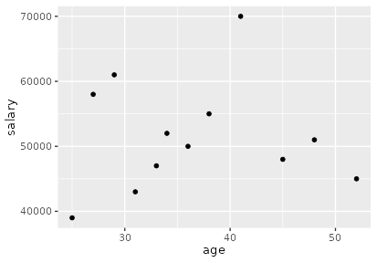

plotnine

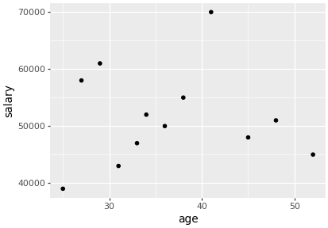

seaborn

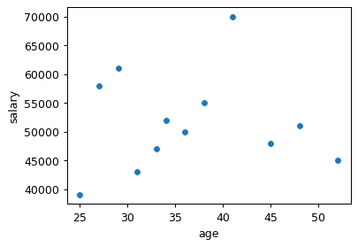

### Färg efter grupp

ggplot2Grund

R (ggplot2)

```
ggplot(df, aes(x = age, y = salary, color = dept)) +
  geom_point(size = 3)
```

plotnine

```
(ggplot(df, aes(x="age", y="salary", color="dept"))
 + geom_point(size=3))
```

seaborn

```
sns.scatterplot(data=df, x="age", y="salary", hue="dept", s=60)
```

`color` (ggplot2) heter `hue` i seaborn. Storlek efter en kolumn: `aes(size = ...)` blir `size="kolumn"` i seaborn. Fast storlek: `size=3` i plotnine men `s=60` i seaborn (en annan skala).

**Visa resultat**

R (ggplot2)

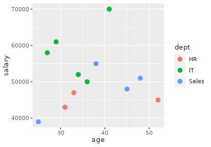

plotnine

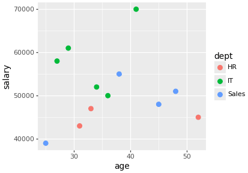

seaborn

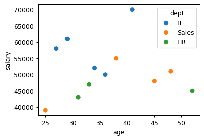

### Titel, axeltexter och tema

ggplot2Grund

R (ggplot2)

```
ggplot(df, aes(age, salary, color = dept)) +
  geom_point() +
  labs(title = "Lön och ålder", x = "Ålder", y = "Lön", color = "Avdelning") +
  theme_minimal()
```

plotnine

```
(ggplot(df, aes("age", "salary", color="dept"))
 + geom_point()
 + labs(title="Lön och ålder", x="Ålder", y="Lön", color="Avdelning")
 + theme_minimal())
```

seaborn

```
sns.set_theme(style="whitegrid")
ax = sns.scatterplot(data=df, x="age", y="salary", hue="dept")
ax.set(title="Lön och ålder", xlabel="Ålder", ylabel="Lön")
ax.legend(title="Avdelning")
```

plotnine: `labs(...)` och `theme_minimal()` är identiska med ggplot2. seaborn: teman väljs med `sns.set_theme(style=...)` (t.ex. `"whitegrid"`, `"darkgrid"`, `"white"`), och titlar sätts på diagrammets *axel* (`ax`) med `ax.set(...)`. Att skriva `ax = sns.scatterplot(...)` sparar diagrammet i en variabel så att du kan ändra det efteråt.

**Visa resultat**

R (ggplot2)

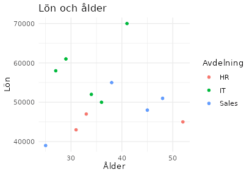

plotnine

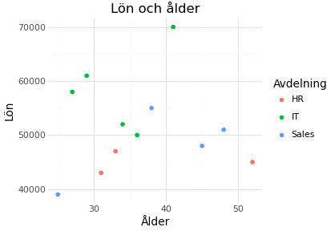

seaborn

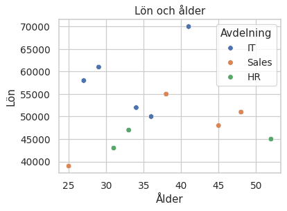

### Stapeldiagram: räkna rader

ggplot2Grund

R (ggplot2)

```
ggplot(df, aes(x = dept)) +
  geom_bar()
```

plotnine

```
(ggplot(df, aes(x="dept"))
 + geom_bar())
```

seaborn

```
sns.countplot(data=df, x="dept")
```

`geom_bar()` räknar själv antalet rader per grupp, och `sns.countplot` gör det också.

**Visa resultat**

R (ggplot2)

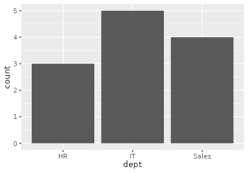

plotnine

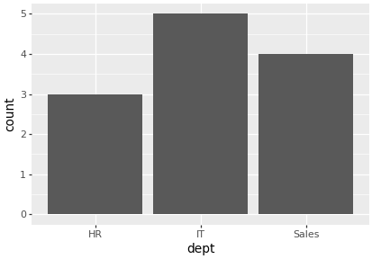

seaborn

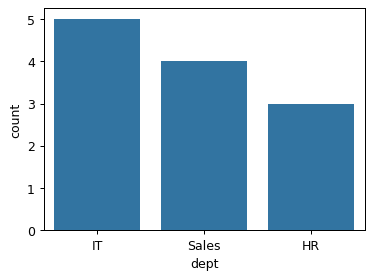

### Stapeldiagram: medelvärden

ggplot2Mellan

R (ggplot2)

```
df |>
  summarise(mean_salary = mean(salary), .by = dept) |>
  ggplot(aes(x = dept, y = mean_salary)) +
  geom_col()
```

plotnine

```
means = df.groupby("dept", as_index=False).agg(mean_salary=("salary", "mean"))
(ggplot(means, aes(x="dept", y="mean_salary"))
 + geom_col())
```

seaborn

```
sns.barplot(data=df, x="dept", y="salary", estimator="mean", errorbar=None)
```

plotnine följer ggplot2: räkna ut värdena först och rita med `geom_col`. seaborn räknar medelvärdet själv (`estimator="mean"`). **Se upp:** som standard ritar seaborn också felstaplar (konfidensintervall), och `errorbar=None` stänger av dem.

**Visa resultat**

R (ggplot2)

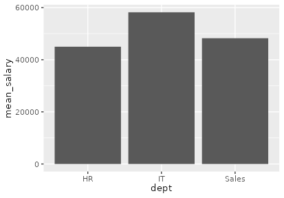

plotnine

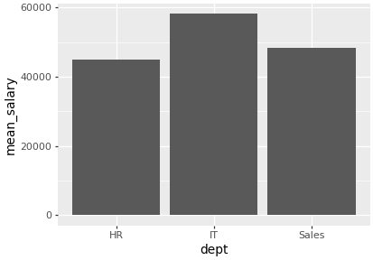

seaborn

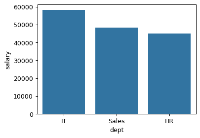

### Grupperade staplar

ggplot2Mellan

R (ggplot2)

```
df |>
  summarise(mean_salary = mean(salary), .by = c(dept, city)) |>
  ggplot(aes(x = dept, y = mean_salary, fill = city)) +
  geom_col(position = "dodge")
```

plotnine

```
means = df.groupby(["dept", "city"], as_index=False).agg(mean_salary=("salary", "mean"))
(ggplot(means, aes(x="dept", y="mean_salary", fill="city"))
 + geom_col(position="dodge"))
```

seaborn

```
sns.barplot(data=df, x="dept", y="salary", hue="city", errorbar=None)
```

`position = "dodge"` (staplar bredvid varandra) är standard i seaborn när du anger `hue`. Staplade staplar: `position="stack"` i plotnine (även standard).

**Visa resultat**

R (ggplot2)

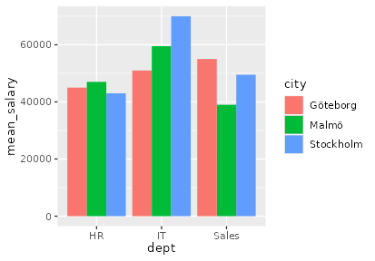

plotnine

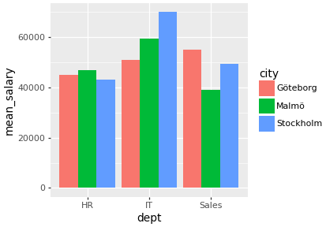

seaborn

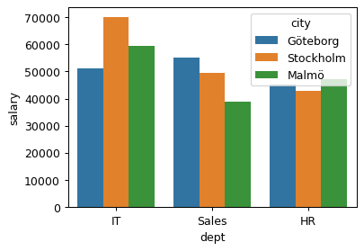

### Histogram

ggplot2Grund

R (ggplot2)

```
ggplot(df, aes(x = salary)) +
  geom_histogram(bins = 6)
```

plotnine

```
(ggplot(df, aes(x="salary"))
 + geom_histogram(bins=6))
```

seaborn

```
sns.histplot(data=df, x="salary", bins=6)
```

Binbredd i stället för antal: `binwidth = 5000` (ggplot2 och plotnine) och `binwidth=5000` (seaborn).

**Visa resultat**

R (ggplot2)

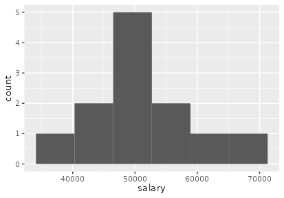

plotnine

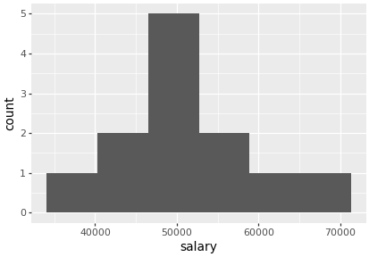

seaborn

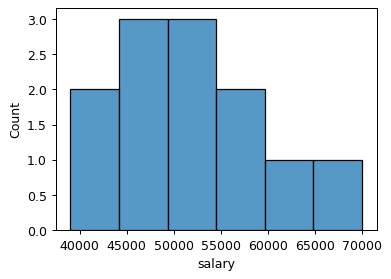

### Täthetskurvor

ggplot2Mellan

R (ggplot2)

```
ggplot(df, aes(x = salary, fill = dept)) +
  geom_density(alpha = 0.4)
```

plotnine

```
(ggplot(df, aes(x="salary", fill="dept"))
 + geom_density(alpha=0.4))
```

seaborn

```
sns.kdeplot(data=df, x="salary", hue="dept", fill=True, alpha=0.4)
```

`alpha` (genomskinlighet) heter likadant. seaborn kallar en täthetskurva för *kde* och fyller ytan med `fill=True`.

**Visa resultat**

R (ggplot2)

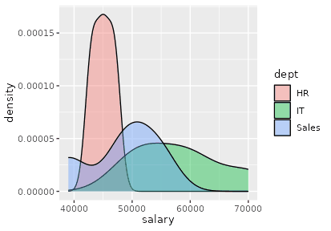

plotnine

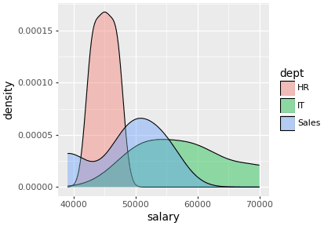

seaborn

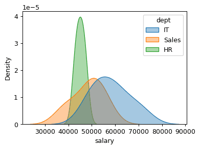

### Lådagram (boxplot)

ggplot2Grund

R (ggplot2)

```
ggplot(df, aes(x = dept, y = salary)) +
  geom_boxplot()
```

plotnine

```
(ggplot(df, aes(x="dept", y="salary"))
 + geom_boxplot())
```

seaborn

```
sns.boxplot(data=df, x="dept", y="salary")
```

Lägg till de enskilda punkterna: `+ geom_jitter(width=0.1)` i plotnine, och `sns.stripplot(data=df, x="dept", y="salary")` efter `boxplot` i seaborn.

**Visa resultat**

R (ggplot2)

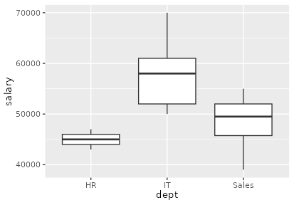

plotnine

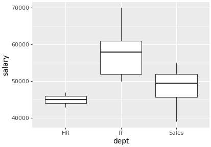

seaborn

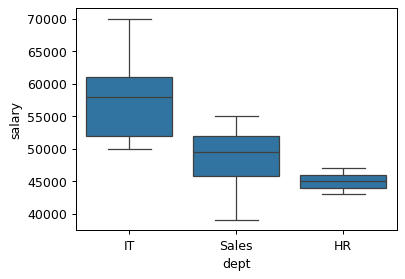

### Linjediagram

ggplot2Grund

R (ggplot2)

```
ggplot(ts, aes(x = month, y = sales, color = product)) +
  geom_line()
```

plotnine

```
(ggplot(ts, aes(x="month", y="sales", color="product"))
 + geom_line())
```

seaborn

```
sns.lineplot(data=ts, x="month", y="sales", hue="product")
```

Med `+ geom_point()` (plotnine) eller `marker="o"` (seaborn) får du punkter på linjen.

**Visa resultat**

R (ggplot2)

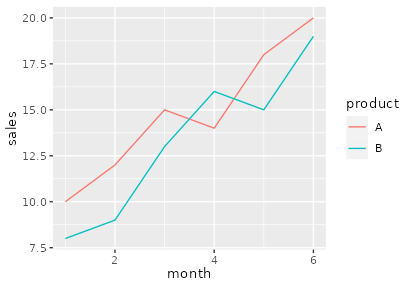

plotnine

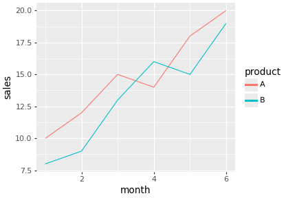

seaborn

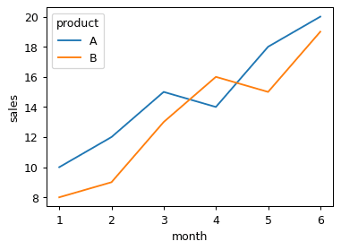

### Ett diagram per grupp (facet)

ggplot2Mellan

R (ggplot2)

```
ggplot(df, aes(x = age, y = salary)) +
  geom_point() +
  facet_wrap(~ dept)
```

plotnine

```
(ggplot(df, aes(x="age", y="salary"))
 + geom_point()
 + facet_wrap("~dept"))
```

seaborn

```
sns.relplot(data=df, x="age", y="salary", col="dept", height=2.2)
```

plotnine: formeln skrivs som text, `facet_wrap("~dept")`. seaborn har särskilda *figur-nivå-funktioner* för detta: `relplot` (punkter/linjer), `catplot` (kategorier) och `displot` (fördelningar), med `col=` och `row=` för uppdelning, som `facet_grid(rad ~ kolumn)`.

**Visa resultat**

R (ggplot2)

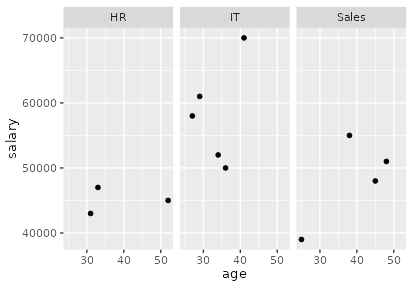

plotnine

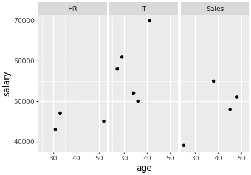

seaborn

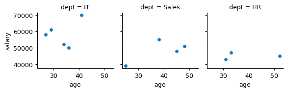

### Regressionslinje

ggplot2Mellan

R (ggplot2)

```
ggplot(df, aes(x = age, y = salary)) +
  geom_point() +
  geom_smooth(method = "lm", se = FALSE)
```

plotnine

```
(ggplot(df, aes(x="age", y="salary"))
 + geom_point()
 + geom_smooth(method="lm", se=False))
```

seaborn

```
sns.regplot(data=df, x="age", y="salary", ci=None)
```

`se = FALSE` (R) heter `se=False` (plotnine) och `ci=None` (seaborn). `TRUE`/`FALSE` skrivs `True`/`False` i Python.

**Visa resultat**

R (ggplot2)

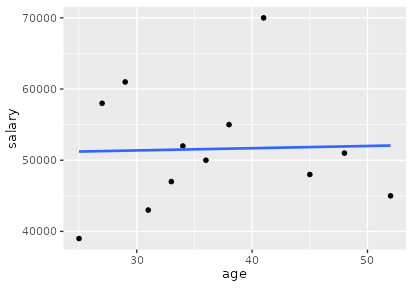

plotnine

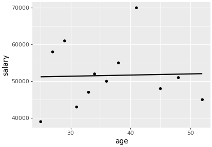

seaborn

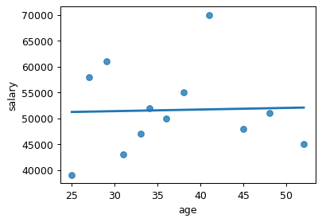

### Vänd på diagrammet (coord_flip)

ggplot2Mellan

R (ggplot2)

```
ggplot(df, aes(x = dept, y = salary)) +
  geom_boxplot() +
  coord_flip()
```

plotnine

```
(ggplot(df, aes(x="dept", y="salary"))
 + geom_boxplot()
 + coord_flip())
```

seaborn

```
sns.boxplot(data=df, x="salary", y="dept")
```

I seaborn byter du bara plats på `x` och `y`. Logaritmisk axel: `scale_y_log10()` (plotnine) och `plt.yscale("log")` (seaborn). Rotera axeltext: `theme(axis_text_x=element_text(rotation=45))` (plotnine) och `plt.xticks(rotation=45)` (seaborn).

**Visa resultat**

R (ggplot2)

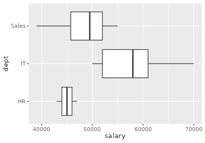

plotnine

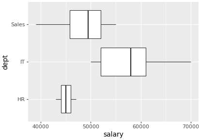

seaborn

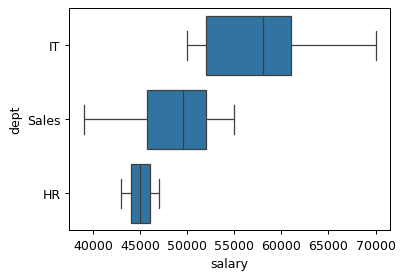

### Egna färger

ggplot2Mellan

R (ggplot2)

```
ggplot(df, aes(age, salary, color = dept)) +
  geom_point(size = 3) +
  scale_color_manual(values = c(IT = "tomato", Sales = "steelblue", HR = "darkgreen"))
```

plotnine

```
(ggplot(df, aes("age", "salary", color="dept"))
 + geom_point(size=3)
 + scale_color_manual(values={"IT": "tomato", "Sales": "steelblue", "HR": "darkgreen"}))
```

seaborn

```
colors = {"IT": "tomato", "Sales": "steelblue", "HR": "darkgreen"}
sns.scatterplot(data=df, x="age", y="salary", hue="dept", palette=colors, s=60)
```

Färgnamn är samma som i R (`"tomato"`, `"steelblue"`, …) eller hexkoder (`"#1f77b4"`). Färdiga paletter: `scale_color_brewer(palette="Set1")` (plotnine) och `palette="Set1"` (seaborn).

**Visa resultat**

R (ggplot2)

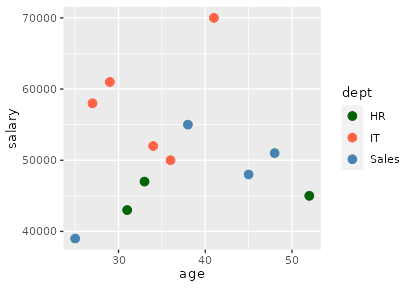

plotnine

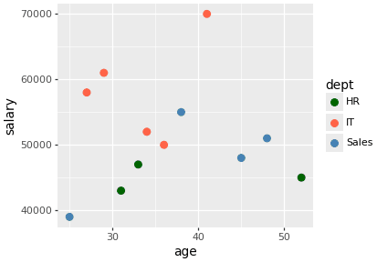

seaborn

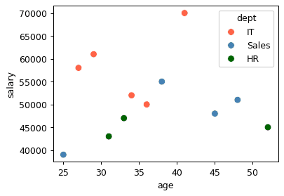

### Hjälplinje och text i diagrammet

ggplot2Mellan

R (ggplot2)

```
ggplot(df, aes(x = age, y = salary)) +
  geom_point() +
  geom_hline(yintercept = 50000, linetype = "dashed") +
  annotate("text", x = 47, y = 52500, label = "Mål")
```

plotnine

```
(ggplot(df, aes(x="age", y="salary"))
 + geom_point()
 + geom_hline(yintercept=50000, linetype="dashed")
 + annotate("text", x=47, y=52500, label="Mål"))
```

seaborn

```
ax = sns.scatterplot(data=df, x="age", y="salary")
ax.axhline(50000, linestyle="--", color="grey")
ax.text(47, 52500, "Mål")
```

I seaborn lägger du till detaljer på axeln med matplotlibs metoder: `ax.axhline` (vågrät linje), `ax.axvline` (lodrät) och `ax.text`.

**Visa resultat**

R (ggplot2)

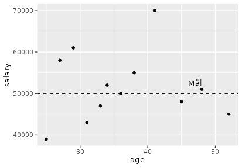

plotnine

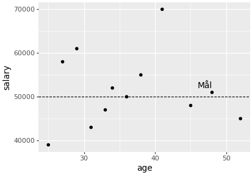

seaborn

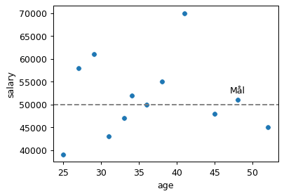

### Värmekarta

ggplot2Avancerad

R (ggplot2)

```
df |>
  summarise(mean_salary = mean(salary), .by = c(dept, city)) |>
  ggplot(aes(x = city, y = dept, fill = mean_salary)) +
  geom_tile()
```

plotnine

```
means = df.groupby(["dept", "city"], as_index=False).agg(mean_salary=("salary", "mean"))
(ggplot(means, aes(x="city", y="dept", fill="mean_salary"))
 + geom_tile())
```

seaborn

```
table = df.pivot_table(index="dept", columns="city", values="salary", aggfunc="mean")
sns.heatmap(table, annot=True, fmt=".0f", cmap="viridis")
```

seaborn vill ha datan som en **bred tabell** (rader = dept, kolumner = city) och den tabellen skapar du med `pivot_table`, det du lärt dig under tidyr. plotnine använder lång form precis som ggplot2.

**Visa resultat**

R (ggplot2)

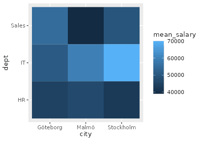

plotnine

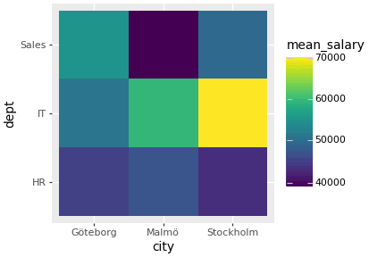

seaborn

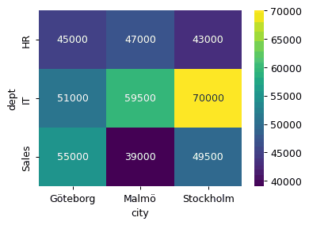

### Sortera staplarna (fct_reorder)

ggplot2Avancerad

R (ggplot2)

```
df |>
  summarise(mean_salary = mean(salary), .by = dept) |>
  ggplot(aes(x = fct_reorder(dept, mean_salary), y = mean_salary)) +
  geom_col()
```

plotnine

```
means = (df.groupby("dept", as_index=False)
           .agg(mean_salary=("salary", "mean"))
           .sort_values("mean_salary"))
means["dept"] = pd.Categorical(means["dept"], categories=means["dept"])
(ggplot(means, aes(x="dept", y="mean_salary"))
 + geom_col())
```

seaborn

```
order = df.groupby("dept")["salary"].mean().sort_values().index
sns.barplot(data=df, x="dept", y="salary", order=order, errorbar=None)
```

plotnine sorterar staplarna efter kategoriernas ordning (se forcats), så gör `dept` till en kategori sorterad efter medelvärdet. seaborn har argumentet `order=` som tar en lista med grupper i önskad ordning.

**Visa resultat**

R (ggplot2)

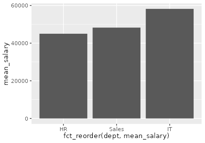

plotnine

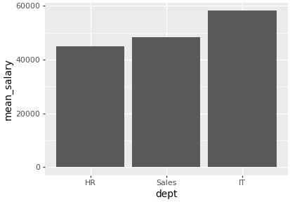

seaborn

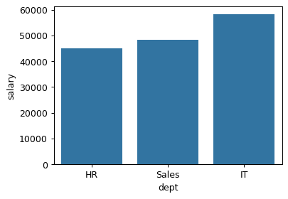

### Flera diagram bredvid varandra (patchwork)

ggplot2Avancerad

R (ggplot2)

```
p1 <- ggplot(df, aes(x = salary)) + geom_histogram(bins = 6)
p2 <- ggplot(df, aes(x = dept, y = salary)) + geom_boxplot()
p1 + p2
```

plotnine

```
p1 = ggplot(df, aes(x="salary")) + geom_histogram(bins=6)
p2 = ggplot(df, aes(x="dept", y="salary")) + geom_boxplot()
p1 | p2
```

seaborn

```
fig, axes = plt.subplots(1, 2, figsize=(8, 3))
sns.histplot(data=df, x="salary", bins=6, ax=axes[0])
sns.boxplot(data=df, x="dept", y="salary", ax=axes[1])
```

plotnine har (från version 0.14) `|` för sida vid sida och `/` för ovanpå varandra, som `patchwork`. I seaborn skapar du först en rad rutor med `plt.subplots(rader, kolumner)` och ritar sedan i varje ruta med `ax=`.

**Visa resultat**

R (ggplot2)

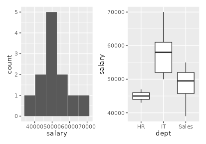

plotnine

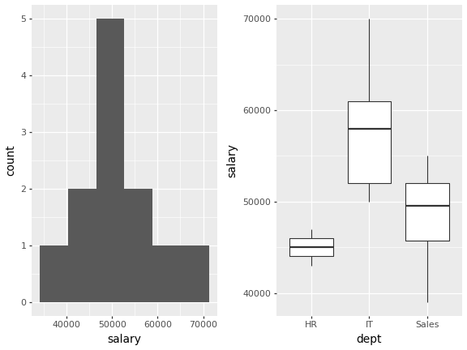

seaborn

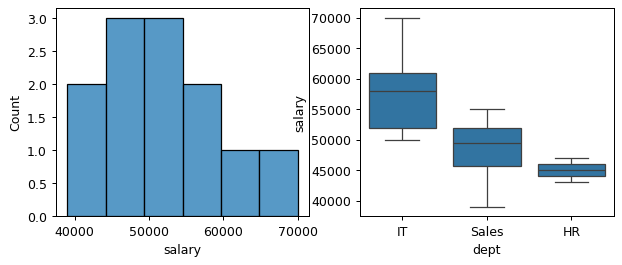

### Spara diagrammet som bild

ggplot2Grund

R (ggplot2)

```
p <- ggplot(df, aes(age, salary)) + geom_point()
ggsave("plot.png", p, width = 6, height = 4, dpi = 150)
```

plotnine

```
p = ggplot(df, aes(x="age", y="salary")) + geom_point()
p.save("plot.png", width=6, height=4, dpi=150)
```

seaborn

```
plt.figure(figsize=(6, 4))
sns.scatterplot(data=df, x="age", y="salary")
plt.savefig("plot.png", dpi=150, bbox_inches="tight")
```

Storleken anges i tum (samma som ggsave). seaborn: ange storleken **innan** du ritar med `plt.figure(figsize=(bredd, höjd))`, och spara efteråt med `plt.savefig`. Filändelsen bestämmer format: `.png`, `.pdf`, `.svg`. `bbox_inches="tight"` klipper bort onödig marginal.

**Visa resultat**

R (ggplot2)

```r
[1] "plot.png"
```

plotnine

Ingen utskrift. Koden gör något i bakgrunden, till exempel sparar en fil.

seaborn

Ingen utskrift. Koden gör något i bakgrunden, till exempel sparar en fil.

### Värden på staplarna

ggplot2Mellan

R (ggplot2)

```
df |>
  summarise(mean_salary = mean(salary), .by = dept) |>
  ggplot(aes(x = dept, y = mean_salary)) +
  geom_col() +
  geom_text(aes(label = round(mean_salary)), vjust = -0.3)
```

plotnine

```
means = df.groupby("dept", as_index=False).agg(mean_salary=("salary", "mean"))
means["label"] = means["mean_salary"].round().astype(int)
(ggplot(means, aes(x="dept", y="mean_salary"))
 + geom_col()
 + geom_text(aes(label="label"), va="bottom"))
```

seaborn

```
ax = sns.barplot(data=df, x="dept", y="salary", errorbar=None)
ax.bar_label(ax.containers[0], fmt="%.0f")
```

plotnine: `geom_text` med en textkolumn (`label`). Placering: `va="bottom"` (ggplot2: `vjust`). seaborn: `bar_label` skriver värdet på varje stapel.

**Visa resultat**

R (ggplot2)

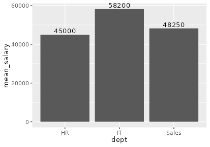

plotnine

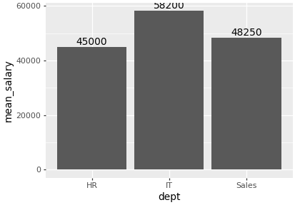

seaborn

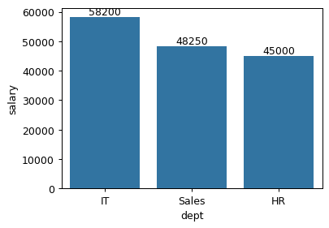

### Olika skala i varje ruta (facet)

ggplot2Mellan

R (ggplot2)

```
ggplot(df, aes(x = age, y = salary)) +
  geom_point() +
  facet_wrap(~ dept, scales = "free_y")
```

plotnine

```
(ggplot(df, aes(x="age", y="salary"))
 + geom_point()
 + facet_wrap("~dept", scales="free_y"))
```

seaborn

```
sns.relplot(data=df, x="age", y="salary", col="dept", height=2.2,
            facet_kws={"sharey": False})
```

`scales = "free_y"` (var ruta får egen y-axel) blir `scales="free_y"` i plotnine och `facet_kws={"sharey": False}` i seaborn. `"free"` ger fria axlar i båda riktningarna.

**Visa resultat**

R (ggplot2)

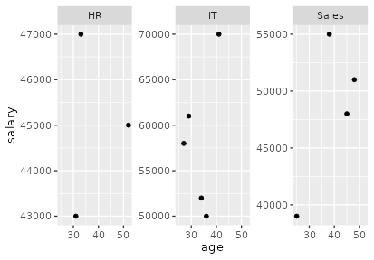

plotnine

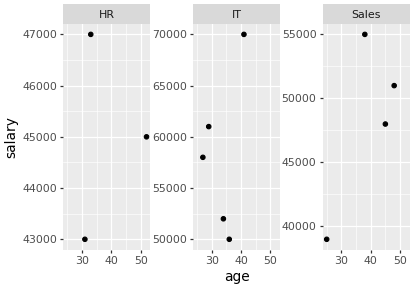

seaborn

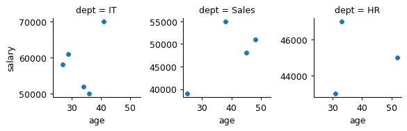

### Datum på x-axeln

ggplot2Mellan

R (ggplot2)

```
ggplot(daily, aes(x = date, y = amount)) +
  geom_line() +
  scale_x_date(date_labels = "%b %d")
```

plotnine

```
(ggplot(daily, aes(x="date", y="amount"))
 + geom_line()
 + scale_x_datetime(date_labels="%b %d"))
```

seaborn

```
import matplotlib.dates as mdates

ax = sns.lineplot(data=daily, x="date", y="amount")
ax.xaxis.set_major_formatter(mdates.DateFormatter("%b %d"))
```

Formatkoderna för datum (`%b %d`) är desamma som i R. I plotnine heter funktionen `scale_x_datetime` när kolumnen är en Pandas-datumkolumn (`scale_x_date` för Pythons `date`-objekt). I seaborn formaterar du axeln med matplotlib: `mdates.DateFormatter`. Månadsnamnen blir på engelska.

**Visa resultat**

R (ggplot2)

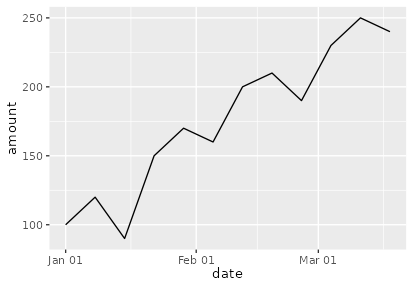

plotnine

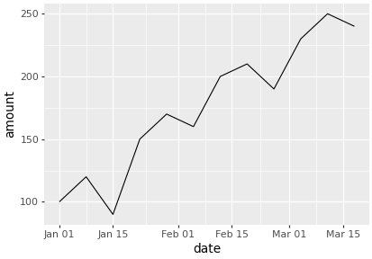

seaborn

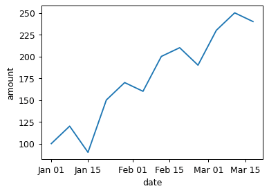

## Fallgropar

Det som oftast går snett när man kommer från R

Här är de sakerna som brukar överraska den som kan tidyverse. Varje exempel är körd och verifierad. Tabellen `df` är samma som under dplyr.

**Tabellen df (12 anställda):**

R

```
library(tidyverse)
df <- tibble(
  id     = 1:12,
  name   = c("Anna", "Bo", "Cia", "Dag", "Eva", "Finn", "Gun", "Hugo", "Ida", "Jon", "Kim", "Lo"),
  city   = c("Göteborg", "Stockholm", "Malmö", "Göteborg", "Stockholm", "Malmö",
             "Göteborg", "Stockholm", "Malmö", "Göteborg", "Stockholm", "Malmö"),
  dept   = c("IT", "Sales", "IT", "HR", "IT", "Sales", "Sales", "HR", "IT", "IT", "Sales", "HR"),
  salary = c(52000, 48000, 61000, 45000, 70000, 39000, 55000, 43000, 58000, NA, 51000, 47000),
  age    = c(34, 45, 29, 52, 41, 25, 38, 31, 27, 36, 48, 33)
)
depts <- tibble(
  dept = c("IT", "Sales", "HR", "Legal"),
  boss = c("Kalle", "Lena", "Mats", "Nina")
)
```

Pandas

```
import pandas as pd
import numpy as np

df = pd.DataFrame({
    "id":     [1, 2, 3, 4, 5, 6, 7, 8, 9, 10, 11, 12],
    "name":   ["Anna", "Bo", "Cia", "Dag", "Eva", "Finn", "Gun", "Hugo", "Ida", "Jon", "Kim", "Lo"],
    "city":   ["Göteborg", "Stockholm", "Malmö", "Göteborg", "Stockholm", "Malmö",
               "Göteborg", "Stockholm", "Malmö", "Göteborg", "Stockholm", "Malmö"],
    "dept":   ["IT", "Sales", "IT", "HR", "IT", "Sales", "Sales", "HR", "IT", "IT", "Sales", "HR"],
    "salary": [52000, 48000, 61000, 45000, 70000, 39000, 55000, 43000, 58000, None, 51000, 47000],
    "age":    [34, 45, 29, 52, 41, 25, 38, 31, 27, 36, 48, 33],
})
depts = pd.DataFrame({
    "dept": ["IT", "Sales", "HR", "Legal"],
    "boss": ["Kalle", "Lena", "Mats", "Nina"],
})
```

Polars

```
import polars as pl
import polars.selectors as cs

df = pl.DataFrame({
    "id":     [1, 2, 3, 4, 5, 6, 7, 8, 9, 10, 11, 12],
    "name":   ["Anna", "Bo", "Cia", "Dag", "Eva", "Finn", "Gun", "Hugo", "Ida", "Jon", "Kim", "Lo"],
    "city":   ["Göteborg", "Stockholm", "Malmö", "Göteborg", "Stockholm", "Malmö",
               "Göteborg", "Stockholm", "Malmö", "Göteborg", "Stockholm", "Malmö"],
    "dept":   ["IT", "Sales", "IT", "HR", "IT", "Sales", "Sales", "HR", "IT", "IT", "Sales", "HR"],
    "salary": [52000, 48000, 61000, 45000, 70000, 39000, 55000, 43000, 58000, None, 51000, 47000],
    "age":    [34, 45, 29, 52, 41, 25, 38, 31, 27, 36, 48, 33],
})
depts = pl.DataFrame({
    "dept": ["IT", "Sales", "HR", "Legal"],
    "boss": ["Kalle", "Lena", "Mats", "Nina"],
})
```

### Glöm inte att spara resultatet

FallgroparGrund

R

```
df <- mutate(df, salary_k = salary / 1000)
names(df)
```

Pandas

```
df.assign(salary_k=df["salary"] / 1000)       # df ändras INTE
df = df.assign(salary_k=df["salary"] / 1000)  # nu sparas det
df.columns.tolist()
```

Polars

```
df.with_columns(salary_k=pl.col("salary") / 1000)       # df ändras INTE
df = df.with_columns(salary_k=pl.col("salary") / 1000)  # nu sparas det
df.columns
```

Pandas- och Polars-funktioner **returnerar en ny tabell** och ändrar inte den gamla. Ser du ingen förändring: du har glömt `df = ...`. (R gör likadant: `mutate(df, ...)` sparar inget utan `df <-`.) Pandas har ett `inplace=True` som du ser i äldre kod, men undvik det.

**Visa resultat**

R

```r
[1] "id"       "name"     "city"     "dept"     "salary"   "age"      "salary_k"
```

Pandas

```
['id', 'name', 'city', 'dept', 'salary', 'age', 'salary_k']
```

Polars

```
['id', 'name', 'city', 'dept', 'salary', 'age', 'salary_k']
```

### Radetiketter (index) i Pandas

FallgroparMellan

R

```
filter(df, salary > 50000)
```

Pandas

```
df[df["salary"] > 50000].reset_index(drop=True)
```

Polars

```
df.filter(pl.col("salary") > 50000)
```

Pandas-tabeller har ett **index**: en osynlig etikett för varje rad. Filtrerar du behåller raderna sina ursprungliga etiketter (0, 2, 4 …), vilket ofta förvirrar. `reset_index(drop=True)` numrerar om. Efter `groupby` hamnar gruppnamnen i indexet om du inte skriver `as_index=False`. Polars har inget index alls, och det är en av anledningarna till att många tycker det är enklare.

**Visa resultat**

R

```r
# A tibble: 6 × 6
     id name  city      dept  salary   age
  <int> <chr> <chr>     <chr>  <dbl> <dbl>
1     1 Anna  Göteborg  IT     52000    34
2     3 Cia   Malmö     IT     61000    29
3     5 Eva   Stockholm IT     70000    41
4     7 Gun   Göteborg  Sales  55000    38
5     9 Ida   Malmö     IT     58000    27
6    11 Kim   Stockholm Sales  51000    48
```

Pandas

```
   id  name       city   dept   salary  age
0   1  Anna   Göteborg     IT  52000.0   34
1   3   Cia      Malmö     IT  61000.0   29
2   5   Eva  Stockholm     IT  70000.0   41
3   7   Gun   Göteborg  Sales  55000.0   38
4   9   Ida      Malmö     IT  58000.0   27
5  11   Kim  Stockholm  Sales  51000.0   48
```

Polars

```
shape: (6, 6)
┌─────┬──────┬───────────┬───────┬────────┬─────┐
│ id  ┆ name ┆ city      ┆ dept  ┆ salary ┆ age │
│ --- ┆ ---  ┆ ---       ┆ ---   ┆ ---    ┆ --- │
│ i64 ┆ str  ┆ str       ┆ str   ┆ i64    ┆ i64 │
╞═════╪══════╪═══════════╪═══════╪════════╪═════╡
│ 1   ┆ Anna ┆ Göteborg  ┆ IT    ┆ 52000  ┆ 34  │
│ 3   ┆ Cia  ┆ Malmö     ┆ IT    ┆ 61000  ┆ 29  │
│ 5   ┆ Eva  ┆ Stockholm ┆ IT    ┆ 70000  ┆ 41  │
│ 7   ┆ Gun  ┆ Göteborg  ┆ Sales ┆ 55000  ┆ 38  │
│ 9   ┆ Ida  ┆ Malmö     ┆ IT    ┆ 58000  ┆ 27  │
│ 11  ┆ Kim  ┆ Stockholm ┆ Sales ┆ 51000  ┆ 48  │
└─────┴──────┴───────────┴───────┴────────┴─────┘
```

### Polars: kolumner i samma with_columns kan inte använda varandra

FallgroparMellan

R

```
mutate(df, bonus = salary * 0.1, total = salary + bonus)
```

Pandas

```
df.assign(
    bonus=lambda d: d["salary"] * 0.1,
    total=lambda d: d["salary"] + d["bonus"],
)
```

Polars

```
try:
    df.with_columns(bonus=pl.col("salary") * 0.1, total=pl.col("salary") + pl.col("bonus"))
except pl.exceptions.ColumnNotFoundError:
    print("Fel: bonus finns inte än i samma with_columns")

# rätt sätt: två steg
df.with_columns(bonus=pl.col("salary") * 0.1).with_columns(total=pl.col("salary") + pl.col("bonus"))
```

I `mutate` kan du använda en kolumn du just skapat. I Polars `with_columns` beräknas alla uttryck **samtidigt** utifrån den gamla tabellen, så du får ett fel. Kedja i stället flera `with_columns`.

**Visa resultat**

R

```r
# A tibble: 12 × 8
      id name  city      dept  salary   age bonus total
   <int> <chr> <chr>     <chr>  <dbl> <dbl> <dbl> <dbl>
 1     1 Anna  Göteborg  IT     52000    34  5200 57200
 2     2 Bo    Stockholm Sales  48000    45  4800 52800
 3     3 Cia   Malmö     IT     61000    29  6100 67100
 4     4 Dag   Göteborg  HR     45000    52  4500 49500
 5     5 Eva   Stockholm IT     70000    41  7000 77000
 6     6 Finn  Malmö     Sales  39000    25  3900 42900
 7     7 Gun   Göteborg  Sales  55000    38  5500 60500
 8     8 Hugo  Stockholm HR     43000    31  4300 47300
 9     9 Ida   Malmö     IT     58000    27  5800 63800
10    10 Jon   Göteborg  IT        NA    36    NA    NA
11    11 Kim   Stockholm Sales  51000    48  5100 56100
12    12 Lo    Malmö     HR     47000    33  4700 51700
```

Pandas

```
    id  name       city   dept   salary  age   bonus    total
0    1  Anna   Göteborg     IT  52000.0   34  5200.0  57200.0
1    2    Bo  Stockholm  Sales  48000.0   45  4800.0  52800.0
2    3   Cia      Malmö     IT  61000.0   29  6100.0  67100.0
3    4   Dag   Göteborg     HR  45000.0   52  4500.0  49500.0
4    5   Eva  Stockholm     IT  70000.0   41  7000.0  77000.0
5    6  Finn      Malmö  Sales  39000.0   25  3900.0  42900.0
6    7   Gun   Göteborg  Sales  55000.0   38  5500.0  60500.0
7    8  Hugo  Stockholm     HR  43000.0   31  4300.0  47300.0
8    9   Ida      Malmö     IT  58000.0   27  5800.0  63800.0
9   10   Jon   Göteborg     IT      NaN   36     NaN      NaN
10  11   Kim  Stockholm  Sales  51000.0   48  5100.0  56100.0
11  12    Lo      Malmö     HR  47000.0   33  4700.0  51700.0
```

Polars

```
Fel: bonus finns inte än i samma with_columns
shape: (12, 8)
┌─────┬──────┬───────────┬───────┬────────┬─────┬────────┬─────────┐
│ id  ┆ name ┆ city      ┆ dept  ┆ salary ┆ age ┆ bonus  ┆ total   │
│ --- ┆ ---  ┆ ---       ┆ ---   ┆ ---    ┆ --- ┆ ---    ┆ ---     │
│ i64 ┆ str  ┆ str       ┆ str   ┆ i64    ┆ i64 ┆ f64    ┆ f64     │
╞═════╪══════╪═══════════╪═══════╪════════╪═════╪════════╪═════════╡
│ 1   ┆ Anna ┆ Göteborg  ┆ IT    ┆ 52000  ┆ 34  ┆ 5200.0 ┆ 57200.0 │
│ 2   ┆ Bo   ┆ Stockholm ┆ Sales ┆ 48000  ┆ 45  ┆ 4800.0 ┆ 52800.0 │
│ 3   ┆ Cia  ┆ Malmö     ┆ IT    ┆ 61000  ┆ 29  ┆ 6100.0 ┆ 67100.0 │
│ 4   ┆ Dag  ┆ Göteborg  ┆ HR    ┆ 45000  ┆ 52  ┆ 4500.0 ┆ 49500.0 │
│ 5   ┆ Eva  ┆ Stockholm ┆ IT    ┆ 70000  ┆ 41  ┆ 7000.0 ┆ 77000.0 │
│ 6   ┆ Finn ┆ Malmö     ┆ Sales ┆ 39000  ┆ 25  ┆ 3900.0 ┆ 42900.0 │
│ 7   ┆ Gun  ┆ Göteborg  ┆ Sales ┆ 55000  ┆ 38  ┆ 5500.0 ┆ 60500.0 │
│ 8   ┆ Hugo ┆ Stockholm ┆ HR    ┆ 43000  ┆ 31  ┆ 4300.0 ┆ 47300.0 │
…
```

### Polars: ordningen på grupperna är slumpmässig

FallgroparMellan

R

```
count(df, dept)
```

Pandas

```
df.groupby("dept", as_index=False).size()
```

Polars

```
df.group_by("dept").len().sort("dept")
```

dplyr och Pandas sorterar grupperna efter nyckeln. **Polars gör det inte** och kan ge grupperna i olika ordning vid olika körningar. Lägg alltid till `.sort("dept")` (eller `maintain_order=True` för ordningen de förekommer i) när du vill ha en stabil ordning.

**Visa resultat**

R

```r
# A tibble: 3 × 2
  dept      n
  <chr> <int>
1 HR        3
2 IT        5
3 Sales     4
```

Pandas

```
    dept  size
0     HR     3
1     IT     5
2  Sales     4
```

Polars

```
shape: (3, 2)
┌───────┬─────┐
│ dept  ┆ len │
│ ---   ┆ --- │
│ str   ┆ u32 │
╞═══════╪═════╡
│ HR    ┆ 3   │
│ IT    ┆ 5   │
│ Sales ┆ 4   │
└───────┴─────┘
```

### Jämföra saknade värden

FallgroparMellan

R

```
c(1, NA) == c(1, NA)
```

Pandas

```
import numpy as np

pd.Series([1, np.nan]) == pd.Series([1, np.nan])
```

Polars

```
pl.Series([1, None]) == pl.Series([1, None])
```

I R är `NA == NA` alltid `NA` (okänt). Pandas säger `False` (NaN är aldrig lika med något). Polars säger `null` (okänt), som R. Använd därför alltid `.isna()` / `.is_null()` för att hitta saknade värden, aldrig `==`.

**Visa resultat**

R

```r
[1] TRUE   NA
```

Pandas

```
0     True
1    False
dtype: bool
```

Polars

```
shape: (2,)
Series: '' [bool]
[
	true
	null
]
```

### &, | och parenteser

FallgroparGrund

R

```
filter(df, age > 30, age < 50)
```

Pandas

```
try:
    df[df["age"] > 30 & df["age"] < 50]      # fel: parentes saknas
except Exception as e:
    print(type(e).__name__)

df[(df["age"] > 30) & (df["age"] < 50)]      # rätt
```

Polars

```
try:
    df.filter(pl.col("age") > 30 & pl.col("age") < 50)      # fel: parentes saknas
except Exception as e:
    print(type(e).__name__)

df.filter((pl.col("age") > 30) & (pl.col("age") < 50))      # rätt
```

`&` binder hårdare än `>` i Python, så utan parenteser tolkas `30 & df["age"]` först. Du får ett kryptiskt felmeddelande. **Regel:** varje delvillkor i egen parentes. Det går att skriva flera villkor med komma i Polars `filter(a, b)` utan `&`.

**Visa resultat**

R

```r
# A tibble: 8 × 6
     id name  city      dept  salary   age
  <int> <chr> <chr>     <chr>  <dbl> <dbl>
1     1 Anna  Göteborg  IT     52000    34
2     2 Bo    Stockholm Sales  48000    45
3     5 Eva   Stockholm IT     70000    41
4     7 Gun   Göteborg  Sales  55000    38
5     8 Hugo  Stockholm HR     43000    31
6    10 Jon   Göteborg  IT        NA    36
7    11 Kim   Stockholm Sales  51000    48
8    12 Lo    Malmö     HR     47000    33
```

Pandas

```
ValueError
    id  name       city   dept   salary  age
0    1  Anna   Göteborg     IT  52000.0   34
1    2    Bo  Stockholm  Sales  48000.0   45
4    5   Eva  Stockholm     IT  70000.0   41
6    7   Gun   Göteborg  Sales  55000.0   38
7    8  Hugo  Stockholm     HR  43000.0   31
9   10   Jon   Göteborg     IT      NaN   36
10  11   Kim  Stockholm  Sales  51000.0   48
11  12    Lo      Malmö     HR  47000.0   33
```

Polars

```
TypeError
shape: (8, 6)
┌─────┬──────┬───────────┬───────┬────────┬─────┐
│ id  ┆ name ┆ city      ┆ dept  ┆ salary ┆ age │
│ --- ┆ ---  ┆ ---       ┆ ---   ┆ ---    ┆ --- │
│ i64 ┆ str  ┆ str       ┆ str   ┆ i64    ┆ i64 │
╞═════╪══════╪═══════════╪═══════╪════════╪═════╡
│ 1   ┆ Anna ┆ Göteborg  ┆ IT    ┆ 52000  ┆ 34  │
│ 2   ┆ Bo   ┆ Stockholm ┆ Sales ┆ 48000  ┆ 45  │
│ 5   ┆ Eva  ┆ Stockholm ┆ IT    ┆ 70000  ┆ 41  │
│ 7   ┆ Gun  ┆ Göteborg  ┆ Sales ┆ 55000  ┆ 38  │
│ 8   ┆ Hugo ┆ Stockholm ┆ HR    ┆ 43000  ┆ 31  │
│ 10  ┆ Jon  ┆ Göteborg  ┆ IT    ┆ null   ┆ 36  │
│ 11  ┆ Kim  ┆ Stockholm ┆ Sales ┆ 51000  ┆ 48  │
│ 12  ┆ Lo   ┆ Malmö     ┆ HR    ┆ 47000  ┆ 33  │
└─────┴──────┴───────────┴───────┴────────┴─────┘
```

### Text som ett värde i Polars: använd pl.lit

FallgroparGrund

R

```
mutate(df, kind = "employee")
```

Pandas

```
df.assign(kind="employee")
```

Polars

```
df.with_columns(kind=pl.lit("employee"))
```

I Polars tolkas en vanlig text som ett **kolumnnamn**. `with_columns(kind="employee")` letar efter en kolumn som heter *employee* och ger felmeddelandet `ColumnNotFoundError`. Vill du ha själva texten skriver du `pl.lit("employee")` (*literal*). Samma gäller inuti `when/then/otherwise`.

**Visa resultat**

R

```r
# A tibble: 12 × 7
      id name  city      dept  salary   age kind
   <int> <chr> <chr>     <chr>  <dbl> <dbl> <chr>
 1     1 Anna  Göteborg  IT     52000    34 employee
 2     2 Bo    Stockholm Sales  48000    45 employee
 3     3 Cia   Malmö     IT     61000    29 employee
 4     4 Dag   Göteborg  HR     45000    52 employee
 5     5 Eva   Stockholm IT     70000    41 employee
 6     6 Finn  Malmö     Sales  39000    25 employee
 7     7 Gun   Göteborg  Sales  55000    38 employee
 8     8 Hugo  Stockholm HR     43000    31 employee
 9     9 Ida   Malmö     IT     58000    27 employee
10    10 Jon   Göteborg  IT        NA    36 employee
11    11 Kim   Stockholm Sales  51000    48 employee
12    12 Lo    Malmö     HR     47000    33 employee
```

Pandas

```
    id  name       city   dept   salary  age      kind
0    1  Anna   Göteborg     IT  52000.0   34  employee
1    2    Bo  Stockholm  Sales  48000.0   45  employee
2    3   Cia      Malmö     IT  61000.0   29  employee
3    4   Dag   Göteborg     HR  45000.0   52  employee
4    5   Eva  Stockholm     IT  70000.0   41  employee
5    6  Finn      Malmö  Sales  39000.0   25  employee
6    7   Gun   Göteborg  Sales  55000.0   38  employee
7    8  Hugo  Stockholm     HR  43000.0   31  employee
8    9   Ida      Malmö     IT  58000.0   27  employee
9   10   Jon   Göteborg     IT      NaN   36  employee
10  11   Kim  Stockholm  Sales  51000.0   48  employee
11  12    Lo      Malmö     HR  47000.0   33  employee
```

Polars

```
shape: (12, 7)
┌─────┬──────┬───────────┬───────┬────────┬─────┬──────────┐
│ id  ┆ name ┆ city      ┆ dept  ┆ salary ┆ age ┆ kind     │
│ --- ┆ ---  ┆ ---       ┆ ---   ┆ ---    ┆ --- ┆ ---      │
│ i64 ┆ str  ┆ str       ┆ str   ┆ i64    ┆ i64 ┆ str      │
╞═════╪══════╪═══════════╪═══════╪════════╪═════╪══════════╡
│ 1   ┆ Anna ┆ Göteborg  ┆ IT    ┆ 52000  ┆ 34  ┆ employee │
│ 2   ┆ Bo   ┆ Stockholm ┆ Sales ┆ 48000  ┆ 45  ┆ employee │
│ 3   ┆ Cia  ┆ Malmö     ┆ IT    ┆ 61000  ┆ 29  ┆ employee │
│ 4   ┆ Dag  ┆ Göteborg  ┆ HR    ┆ 45000  ┆ 52  ┆ employee │
│ 5   ┆ Eva  ┆ Stockholm ┆ IT    ┆ 70000  ┆ 41  ┆ employee │
│ 6   ┆ Finn ┆ Malmö     ┆ Sales ┆ 39000  ┆ 25  ┆ employee │
│ 7   ┆ Gun  ┆ Göteborg  ┆ Sales ┆ 55000  ┆ 38  ┆ employee │
│ 8   ┆ Hugo ┆ Stockholm ┆ HR    ┆ 43000  ┆ 31  ┆ employee │
│ 9   ┆ Ida  ┆ Malmö     ┆ IT    ┆ 58000  ┆ 27  ┆ employee │
…
```

### Två namn, samma tabell

FallgroparMellan

R

```
a <- df
a$new <- 1
"new" %in% names(df)
```

Pandas

```
a = df
a["new"] = 1          # ändrar även df!
"new" in df.columns
```

Polars

```
a = df
a = a.with_columns(new=pl.lit(1))
"new" in df.columns
```

R kopierar automatiskt när du ändrar (*copy-on-modify*). I Pandas är `a = df` **inte en kopia** utan ett andra namn på samma tabell, så ändringen syns i båda. Gör `a = df.copy()` när du vill ha en egen. Polars-tabeller ändras aldrig på plats, så där uppstår inte problemet.

**Visa resultat**

R

```r
[1] FALSE
```

Pandas

```
True
```

Polars

```
False
```

### Ändra värden i vissa rader

FallgroparMellan

R

```
mutate(df, salary = if_else(age > 40, 0, salary))
```

Pandas

```
df.assign(salary=df["salary"].mask(df["age"] > 40, 0))
```

Polars

```
df.with_columns(pl.when(pl.col("age") > 40).then(0).otherwise(pl.col("salary")).alias("salary"))
```

`mask(villkor, nytt_värde)` byter ut värden där villkoret stämmer. Ett klassiskt Pandas-misstag är `df[df["age"] > 40]["salary"] = 0`. Det ändrar en tillfällig kopia och gör alltså **ingenting** med df. Rätt är `df.loc[df["age"] > 40, "salary"] = 0` (ändrar df på plats) eller `assign`/`mask` som ovan.

**Visa resultat**

R

```r
# A tibble: 12 × 6
      id name  city      dept  salary   age
   <int> <chr> <chr>     <chr>  <dbl> <dbl>
 1     1 Anna  Göteborg  IT     52000    34
 2     2 Bo    Stockholm Sales      0    45
 3     3 Cia   Malmö     IT     61000    29
 4     4 Dag   Göteborg  HR         0    52
 5     5 Eva   Stockholm IT         0    41
 6     6 Finn  Malmö     Sales  39000    25
 7     7 Gun   Göteborg  Sales  55000    38
 8     8 Hugo  Stockholm HR     43000    31
 9     9 Ida   Malmö     IT     58000    27
10    10 Jon   Göteborg  IT        NA    36
11    11 Kim   Stockholm Sales      0    48
12    12 Lo    Malmö     HR     47000    33
```

Pandas

```
    id  name       city   dept   salary  age
0    1  Anna   Göteborg     IT  52000.0   34
1    2    Bo  Stockholm  Sales      0.0   45
2    3   Cia      Malmö     IT  61000.0   29
3    4   Dag   Göteborg     HR      0.0   52
4    5   Eva  Stockholm     IT      0.0   41
5    6  Finn      Malmö  Sales  39000.0   25
6    7   Gun   Göteborg  Sales  55000.0   38
7    8  Hugo  Stockholm     HR  43000.0   31
8    9   Ida      Malmö     IT  58000.0   27
9   10   Jon   Göteborg     IT      NaN   36
10  11   Kim  Stockholm  Sales      0.0   48
11  12    Lo      Malmö     HR  47000.0   33
```

Polars

```
shape: (12, 6)
┌─────┬──────┬───────────┬───────┬────────┬─────┐
│ id  ┆ name ┆ city      ┆ dept  ┆ salary ┆ age │
│ --- ┆ ---  ┆ ---       ┆ ---   ┆ ---    ┆ --- │
│ i64 ┆ str  ┆ str       ┆ str   ┆ i64    ┆ i64 │
╞═════╪══════╪═══════════╪═══════╪════════╪═════╡
│ 1   ┆ Anna ┆ Göteborg  ┆ IT    ┆ 52000  ┆ 34  │
│ 2   ┆ Bo   ┆ Stockholm ┆ Sales ┆ 0      ┆ 45  │
│ 3   ┆ Cia  ┆ Malmö     ┆ IT    ┆ 61000  ┆ 29  │
│ 4   ┆ Dag  ┆ Göteborg  ┆ HR    ┆ 0      ┆ 52  │
│ 5   ┆ Eva  ┆ Stockholm ┆ IT    ┆ 0      ┆ 41  │
│ 6   ┆ Finn ┆ Malmö     ┆ Sales ┆ 39000  ┆ 25  │
│ 7   ┆ Gun  ┆ Göteborg  ┆ Sales ┆ 55000  ┆ 38  │
│ 8   ┆ Hugo ┆ Stockholm ┆ HR    ┆ 43000  ┆ 31  │
│ 9   ┆ Ida  ┆ Malmö     ┆ IT    ┆ 58000  ┆ 27  │
…
```

### Heltal med saknade värden

FallgroparMellan

R

```
class(c(1L, 2L, NA))
```

Pandas

```
pd.Series([1, 2, None]).dtype
```

Polars

```
pl.Series([1, 2, None]).dtype
```

En heltalskolumn med saknade värden blir **decimaltal** (`float64`) i Pandas, eftersom NaN är ett decimaltal. Polars behåller heltal (`Int64`) och har `null`. Skillnaden syns när du skriver ut eller sparar: `1` blir `1.0` i Pandas. Vill du behålla heltal i Pandas: `astype("Int64")` (stort I).

**Visa resultat**

R

```r
[1] "integer"
```

Pandas

```
dtype('float64')
```

Polars

```
Int64
```